# Evaluation of Diagnostic Concordance Between Algorithms for Parkinson’s Disease Dementia

Martina Mana

Josef Mana

josef.mana@lf1.cuni.cz

Tereza Uhrova

tereza.uhrova@vfn.cz

Robert Jech

jech@cesnet.cz

Ondrej Bezdicek

ondrej.bezdicek@gmail.com

Abstract

```r
library(targets)
library(tidyverse)
library(gt)
library(patchwork)

upstore <- here::here(tar_config_get("store"))
tar_source(here::here("R"))
```

```
## tar_source() only sources R scripts. Ignoring non-R files:
## /Users/josefmana/Desktop/clinical psychology/demcrit/R/.DS_Store
```

```r
data_all <- tar_read(raw_data_all, store = upstore)
data <- tar_read(raw_data, store = upstore)
vars <- tar_read(variables, store = upstore)
algos <- tar_read(pdd_data, store = upstore)$algorithms
rates <- tar_read(rate_summaries, store = upstore)

pres <- tar_read(pdd_data, store = upstore)$PDD |>
  mutate(present = if_else(is.na(PDD), 0, 1)) |>
  select(id, type, present) |>
  pivot_wider(names_from = type, values_from = present) |>
  column_to_rownames("id")
```

# Introduction

Parkinson’s disease (PD) is a neurodegenerative disorder typically characterized by a progressive onset of motor symptoms, including rigidity, bradykinesia, postural instability and resting tremor. Moreover, patients suffer from a range of non-motor impairments (Postuma et al. 2015), particularly cognitive decline. This factor might result in Parkinson’s disease dementia (PDD) in a subset of patients (Meireles and Massano 2012).

According to a recent meta-analysis, approximately one-quarter of PD patients are likely to be diagnosed with PDD (Sousa et al. 2022). However, reported PDD rate estimates vary widely, ranging from 14% up to 55%, depending on the methodological criteria employed. Moreover, factors such as patients’ sex (Cereda et al. 2016), age and disease duration appear to modulate the risk of cognitive decline and PDD (Oh et al. 2016; Rana et al. 2011).

Despite the clinical relevance of PDD, its diagnosis remains complex. A milestone in research of PDD was the publication of diagnostic criteria established in 2007 by the International Parkinson and Movement Disorder Society (MDS) (Dubois et al. 2007). In these criteria, the MDS introduced a two-levelled system for PDD detection. Level I consists of brief cognitive assessments, while Level II involves comprehensive neuropsychological testing across cognitive domains (Emre et al. 2007).

The original Level I algorithm included eight conditions that had to be satisfied simultaneously in order to diagnose probable PDD. These included: 1) diagnosis of PD proposed by the Queen Square Brain Bank; 2) PD onset prior to the PDD emergence; 3) evidence of global cognitive impairment (MMSE score < 26 points); 4) cognitive deficit interference with the IADL (assessed by the pill questionnaire or caregiver interview); 5) impairment in at least two cognitive domains, namely memory, attention, visuo-constructive abilities and executive function; 6) there was absence of Major Depressive Disorder; 7) absence of delirium; and 8) exclusion of other abnormalities and potential causes of dementia (Dubois et al. 2007).

Currently, efforts are focused on refining this PDD diagnostic framework. A recent call for a change pinpoints limitations regarding the original criteria and suggests various updates to enhance their utility (Kulisevsky et al. 2024). Proposed suggestions include replacement of the Mini-Mental State Examination (MMSE) by the Montreal Cognitive Assessment (MoCA), which is more sensitive to PD-specific cognitive impairment; expansion of instrumental activities of daily living (IADL) evaluation; inclusion of language assessment; recognition of anxiety as one of the neuropsychiatric symptoms relevant in PDD; and integration of biomarkers.

In light of these proposals, the current study aims to evaluate the diagnostic concordance between the original MDS Level I PDD criteria (Emre et al. 2007; Dubois et al. 2007) and a modified framework based on the recent call for change (Kulisevsky et al. 2024). Furthermore, both Level I diagnostic approaches are compared to PDD diagnosed on Level II. The study aims to address the following research objectives (RO): (RO1) To estimate the PDD rate and evaluate the diagnostic variability and concordance across different PDD criteria. (RO2) To identify components **of the diagnostic criteria** contributing to PDD classification variability across the applied criteria. **(RO3) To explore accuracy of Level I screening criteria in predicting Level II PDD classification.**

# Methods

## Participants

```r
continue <- all(!is.na(data$assdate))
stopifnot("Some assessment dates are missing" = continue)

dates <- sapply(c("min", "max"), function(f) {
  date <- do.call(f, list(data$assdate))
  paste(month(date, label = TRUE, abbr = FALSE), year(date))
})
```

This study retrospectively analyzed clinical data from a cohort of patients with PD at the General University Hospital in Prague. All patients were diagnosed with idiopathic PD by a movement disorder specialist according to the MDS Clinical Diagnostic Criteria for PD (Postuma et al. 2015). Clinical records spanning January 2015 to February 2025 were examined. All participants were candidates for Deep Brain Stimulation (DBS) treatment and underwent neuropsychological evaluation conducted by a trained clinical psychologist (OB) as part of standard preoperative assessments for DBS eligibility at the General University Hospital in Prague.

**Consequently, patients with neurological or psychiatric disorder other than PD, including atypical parkinsonism, anticholinergic medication, neurological conditions potentially resulting in cognitive impairment (e.g., stroke, psychoactive substances abuse, epileptic seizures) or gait disorder unresponsive to optimal dopaminergic treatment were excluded from the study. Patients with tremor-dominant PD, rather than predominance of axial symptoms, and better response to dopamingergic treatment were considered preferentially. Nonetheless, axial symptoms such as hypokinetic dysarthria, postural instability and gait freezing/hesitations were not used as a hard exclusion criterion.**

## Neuropsychological Assessment

Cognitive performance was evaluated at both Level I and Level II according to the standard MDS battery for Parkinson’s Disease Mild Cognitive Impairment (PD-MCI) (Litvan et al. 2012; Ondrej Bezdicek et al. 2017). Cognitive performance at Level I was assessed by the MMSE (Stepankova et al. 2015; Folstein, Folstein, and McHugh 1975) and the MoCA (Kopecek et al. 2016; Nasreddine et al. 2005). The comprehensive neuropsychological assessment at Level II evaluated five cognitive domains through specific tests: attention and working memory assessed by Trail Making Test Part A (TMT-A) (O. Bezdicek et al. 2012; Reitan 2004), and WAIS Digit Span Backward (WAIS DSB) (Wechsler 1997), executive function by Categorical Verbal Fluency - Animals (CF-A) (Nikolai et al. 2015), and subtest from the Prague Stroop Test – Colors (PST-C) (Ondřej Bezdicek et al. 2021), language by the WAIS Similarities subtest (Wechsler 1997), and the Boston Naming Test (BNT-60) (Zemanová et al. 2016; Kaplan, Goodglass, and Weintraub 1983), memory by the Rey Auditory Verbal Learning Test (RAVLT-DR) (Frydrychová et al. 2018; Ondrej Bezdicek et al. 2013; Rey 1964) delayed recall, and the Brief Visual Memory Test–Revised (BVMTR-DR) (Havlı́k et al. 2020; Benedict 1997) delayed recall, or WAIS Family Pictures subtest (Wechsler 1997) delayed recall, visuospatial function assessed by the Judgment of Line Orientation Test (JoL) (Benton, Varney, and Hamsher 1983), and Clock Drawing Test (CLOX-I) (Royall, Cordes, and Polk 1998).

The Functional Activities Questionnaire (FAQ) (Ondrej Bezdicek, Nikolai, et al. 2016; Pfeffer et al. 1982) was administered to assess functional impairment. The Beck Depression Inventory-II (BDI-II) (Ciharova et al. 2020; Beck, Steer, and Brown 1996) and State-Trait Anxiety Inventory (STAI) (Spielberger et al. 1983; Mullner, Ruisl, and Farkas 1980) were used to assess neuropsychiatric status.

## Diagnostic algorithms for probable Parkinson’s Disease Dementia

In this study, we applied three distinct sets of diagnostic algorithms for probable PDD at Level I. The first set was based on the original framework (Dubois et al. 2007), which utilized the MMSE as a global cognitive screening tool, supplemented by assessments of attention, executive function, visuospatial abilities, and memory. The second set of algorithms was based on the recent call for change of dementia diagnostic guidelines (Kulisevsky et al. 2024), which advocates for more sensitive cognitive domain assessments in the context of PD. This updated approach incorporated specific items from the MoCA. The third approach applied the Czech version of the shortened Montreal Cognitive Assessment (sMoCA) (Ondrej Bezdicek et al. 2020), a time-efficient modification designed to measure global cognitive performance using a reduced testing protocol that omits items providing redundant information. The sMoCA has been validated in the Czech PD cohort (Ondrej Bezdicek et al. 2020) and shown to be sensitive to cognitive deficits while lowering patient burden (Roalf et al. 2017). We included the sMoCA in our study for its clinical utility in pre-surgical settings, where time restrictions and patients’ fatigue often limit the feasibility of longer assessments. Moreover, the Czech validation study reported comparable diagnostic accuracy between MoCA (AUC = 0.815) and sMoCA (AUC = 0.796) for distinguishing PD-MCI from PD-NC, supporting the sMoCA as a suitable and efficient alternative.

Lastly, the fourth approach followed the Level II protocol for diagnosis of PDD and PD-MCI (Dubois et al. 2007; Litvan et al. 2012). The Level II methodology, including the use of a regression-based normative scoring approach, has been detailed in a prior study (Ondrej Bezdicek et al. 2017). In this study, the thresholds for cognitive impairment at Level II were set at $z \leq -1.5$. All non-cognitive criteria of probable PDD (i.e., diagnosis of PD that developed before dementia and absence of Major Depression, delirium or other abnormalities that obscure diagnosis) held true for all patients in the sample according to the psychiatric and neurological examinations.

```r
algonum <- sapply(c("mmse", "moca", "smoca", "lvlII"), function(i) {
  subset(algos, group == i) |>
    nrow()
})

continue <- !any(algonum == 0)
stopifnot("Some algorithms are missing" = continue)
```

For each of these diagnostic approaches, we applied two operationalizations of deficits in Instrumental Activities of Daily Living (IADL). First, we utilized FAQ item 9, which approximates the pill questionnaire from the original criteria (Dubois et al. 2007) employing a cut-off score of 2 points or higher. Second, we applied the entire Functional Activities Questionnaire (FAQ) as suggested in the call for change (Kulisevsky et al. 2024), employing a cut-off score of 7 points or higher based on Czech normative data (O. Bezdicek, Lukavský, and Preiss 2011). These methodologies resulted in a total of 68 algorithms, which were distributed across different diagnostic criteria: 4 MMSE-based, 60 MoCA-based, 2 sMoCA-based, and 2 based on the Level II battery (see (**fig-tree?**), (**tbl-opers?**) and Appendix (**tbl-algos?**) for the exact specification of each algorithm).

Finally, all patients were systematically evaluated for the presence of neuropsychiatric symptoms, including depression, apathy, anxiety, psychosis, and delirium, by a trained neuropsychiatrist (TU) experienced in the assessment of patients with movement disorders. Because severe psychiatric symptoms form exclusion criteria for the diagnosis of probable PDD (conditions 6–8; p. 1), all patients classified as PDD were double-checked in hospital records to confirm the absence of such confounding symptoms.

```r
table_algorithms(vars)
```

[output not shown]

$$Insert Table 1 here$$

## Theoretical and Empirical Estimands

Following the framework proposed by Lundberg, Johnson, and Stewart (2021), in this study we explicitly connect our research objectives and their corresponding theoretical (i.e., targets of inference) and empirical (i.e., data-driven) estimands to statistical estimates. The theoretical estimand refers to a unit-specific quantity defined over a target population and represents the ideal quantity that would address the research question under optimal conditions, such as access to complete population data or perfect experimental control. In contrast, the empirical estimand corresponds to the quantity that is actually computable using the available dataset, given real-world constraints. **Throughout the study, these estimands guide both the statistical analyses performed and the interpretaiton of the resulting estimates.**

A full description of the study’s estimands and their relation to our research objectives is presented in the Appendix (see (**tbl-estimands?**)). **Briefly, our first objective concerns the rate of probable PDD and its variability introduced by alternative diagnostic algorithms in the population of patients with PD undergoing evaluation for DBS. We therefore estimate the distribution of PDD rates produced by all admissible diagnostic algorithms and evaluate concordance between their classifications. Our second objective examine which diagnostic components drive this variability by assessing how difference in operational definitions systematically influence PDD classification.**

**Importantly, although the DBS candidate cohort differs from the broader PD poulation in several aspects (e.g., age distribution or disease subtypes), certain conclusions derive from these analyses extend beyond our specifici sample. In particular, if substantial discrepancies in classification are observed between diagnostic algorithms when applied to the same patients, the results indicate that the algortihms are not measuring the same underlying construct. Such a finding would imply either poor construct validity at large or, if circumscribed only to DBS candidates, measurement invariance. In contrast, strong concordance observed within a restricted sample would count as evidence of good construct variability for the sample but would not generalize to the broader population.**

**Finally, our third objective evaluates predictive validitiy of Leve I screening for probable PDD relative to comprehensive Level II assessment. Specifically, we rank Level I algorithms according to their accuracy in predictivng Level II PDD classification and develop an exploratory screening model based on reduces subset of cognitive screening indexes. Because this predictive model model depends directly on the empirical distribution of PDD classification and test scores observed in our cohort, the resulting estimates are primarily applicable to populations of DBS candiadte patients rather than the broader PD population.**

## Statistical Analyses

### Variability in Dementia Rate Estimates

To address **the first** study objective, we started by repeatedly assigning each patient the diagnosis of probable PDD based on each PDD algorithm listed in (**tbl-opers?**) (see also (**tbl-algos?**)) resulting in a 190 (patients) $\times$ 68 (algorithms) matrix where each cell indicates whether a patient (row) meets criteria for probable PDD according to an algorithm (column). PDD rate estimates were computed as $\frac{N_{PDD}}{N_{total}}$ separately for each algorithm. The predictive value of age and sex was then evaluated by fitting a set of logistic regressions, one for each algorithm for probable PDD, whereby the probable PDD was predicted by age, sex and their interaction.

### Concordance Between Diagnostic Algorithms

**To evaluate the second study objective**, a set of two class cross-tabulations with associated statistics was computed for each pair of algorithms via the `confusionMatrix()` function from the R package *caret* (Kuhn 2008). For each pair of algorithms, the analysis was repeated twice such that each variable of the pair served once as the reference and once as the predictor. The following measures were used to evaluate pairwise concordance between different algorithms for probable PDD: 1) Cohen’s $\kappa$ with its 95% confidence interval (CI) computed via the `cohen.kappa()` function from the R package *psych* (William Revelle 2024); 2) Accuracy (i.e., the proportion of correct predictions, both true positives and true negatives, among the total number of cases) with its 95% CI; 3) Sensitivity/Recall (i.e., the proportion of true positives); and 4) Specificity (i.e., the proportion of true negatives).

**To assess whether the observed accuracy exceeded what would be expected from trivial classification** the No Information Rate (NIR) was calculated for each pair of algorithms. NIR is the accuracy that could be obtained by always predicting the majority class and in our case it is equivalent to the complement of the PDD rate estimate according to the reference algorithm. The accuracy of prediction was compared to the NIR via a one-sided Exact Binomial Test as implemented by the `binom.test()` R stats function. Reference/predictor pairs associated with p < .05 were considered to show significantly better accuracy than NIR. In other words, for reference/predictor pairs associated with p < .05, we conclude that knowing the probable PDD status according to the predictor algorithm helps to estimate the probable PDD status according to the reference algorithm and the two algorithms thus show substantial concordance.

### Prediction of Level II Criteria

**The third study objective was addressed in two stages. First, a descriptive analysis examined cases where Level II diagnostic algorithms served as the reference and Level I algorithms as a predictors, allowing direct comparison of screening-based and comprehensive diagnostic classifications.**

**Next, to identify a parsimonious screening approximation of PDD classification on Level II, we applied projection predictive variable selection (Piironen and Vehtari 2017a; Piironen, Paasiniemi, and Vehtari 2020) as implemented in the R package *projpred* (Piironen et al. 2025). This approach first fits a comprehensive Bayesian reference model containing all candidate predictors and then searches for smaller submodels whose predictive performance approaches the reference model. In this way, predictor subsets are selected based on their ability to preserve predictive performance rather than on individual parameter’s significance within the reference model, thus substantially reducing risk of overfitting.**

**A Bayesian logistic regression predicting Level II PDD status by all available screening variables served as a reference model.[^1] To mitigate potential risks associated with multicollinearity, the regression parameters were assigned regularize horseshoe priors (Piironen and Vehtari 2017b) as implemented in the `horseshoe()` function from the R package *brms* (Bürkner 2017).**

**Projection predictive variable selection was then used to derive a model with smaller predictor set. Predictive performance was measured by the expected log pointwise predictive density (ELPD) estimated via cross-validation. The smallest submodel achieving predictive performance comparable to the reference model was selected as the final screening model. Details of the model specification, selection procedure, and performance criteria are provided in the Appendix.**

**Following variable selection, the optimal probability threshold for predicting Level II PDD classification was determined using the modified, prevalence-adjusted Youden index proposed by Perkins and Schisterman (2006) as implemented in the R package *pROC* (Robin et al. 2011). The prevalence adjustment parameter was varied between 0.1 and 0.5 to reflect plausible population PDD prevalence.**

### Missing Data

Missing data were handled by complete cases analysis **with respect to PDD classification**. In other words, **only patients from whom all diagnostic algorithms could be applied were included in analyses.**

### Software

Data wrangling and visualizations were done in the *tidyverse* package (Wickham et al. 2019) and tables were formatted in the *gt* package (Iannone et al. 2024). All analyses were conducted within the R (version 4.5.2) software environment for statistical computing (R Core Team 2024). The software code supporting this article is available at https://github.com/josefmana/demcrit.git.

# Results

```r
desc  <- tar_read(sample_description, store = upstore)
algos <- tar_read(algorithms, store = upstore)
pred  <- tar_read(demographic_predictors, store = upstore)
conc  <- tar_read(concordance_statistics, store = upstore)
kappa <- tar_read(kappa_summmaries, store = upstore)
perc  <- rates$table$perc

# Tables of the 'best' and the 'worst' w.r.t. Level II:
approx_acc <- table_levelII_approximations(conc$table, algos, "Accuracy_raw")
approx_bal <- table_levelII_approximations(conc$table, algos, "Balanced Accuracy")

# Total numbers:
n_total <- nrow(data_all)
n_incl <- sum(data$incl)
n_excl <- n_total - n_incl
if (n_excl == 1) {
  excl_txt <- paste0("one patient was excluded due to missing neuropsychological data, resulting in a final sample of ", n_incl, " patients")
} else if (n_excl > 1) {
  excl_txt <- paste0(english::english(n_excl), " patients were excluded due to missing neuropsychological data, resulting in a final sample of ", n_incl, " patients")
} else {
  excl_txt <- "no patients was excluded"
}

# Function for writing M (SD):
msd_txt <- function(x, txt = "", tab = desc$table) {
  paste0(
    subset(tab, variable == x)[ , c("M", "SD")] |> paste(collapse = " (SD = "),
    ")",
    txt
  )
}

# In-text demographic data
sex <- subset(desc$table, variable == "Sex")$N
age <- msd_txt("Age", " years of age")
edu <- msd_txt("Education", " years of education")
dur <- msd_txt("PD duration", " years of disease duration")
updrs_off <- msd_txt("UPDRS III off state", " Unified Parkinson Disease Rating Scale (UPDRS), part III in medication OFF state")
updrs_on <- msd_txt("UPDRS III on state", " Unified Parkinson Disease Rating Scale (UPDRS), part III in medication ON state")
bdi <- msd_txt("BDI-II")
staix1 <- msd_txt("STAI X1")
staix2 <- msd_txt("STAI X2")

# In-text rate estimates
rates_overall <- sapply(c("M", "SD", "Md", "minmax"), \(f) do_summary(perc, 2, f))
rates_FAQ9 <- sapply(c("M", "SD", "Md", "minmax"), \(f) do_summary(perc[grepl("FAQ 9", rates$table$IADL)], 2, f))
rates_FAQtot <- sapply(c("M", "SD", "Md", "minmax"), \(f) do_summary(perc[rates$table$IADL == "FAQ > 7"], 2, f))

# Minimum p-value of logistic regressions:
min_p <- subset(pred$values, quantity == "p-value")$estimate |>
  min() |>
  do_summary(3, "p")

# Type of PD distribution:
type_counts <- data$type_pd |> table(useNA = "always")
type_percs <- 100 * prop.table(type_counts)
type_print <- paste(type_counts, paste0("(", do_summary(type_percs, 1), "%)"), sep = " ")
names(type_print) <- ifelse(is.na(names(type_counts)), "missing", names(type_counts))
```

## Sample Description

A total of 203 patients were considered for the study, out of which **thirteen patients were excluded due to missing neuropsychological data, resulting in a final sample of 190 patients**. **Demographical, clinical and** cognitive characteristics of the sample are summarized in (**tbl-desc?**). Descriptive statistics for neuropsychiatric symptoms indicated within average levels of depressive and anxiety symptoms in our cohort, with the average BDI-II of 10.71 (SD = 6.97), average STAI X1 of 38.98 (SD = 9.11), and average STAI X2 of 40.23 (SD = 7.80). However, according to the psychiatric assessment, none of the patients with probable PDD was suffering from the major depressive disorder, delirium or other neuropsychiatric abnormalities that would exclude the diagnosis.

```r
desc$gtable |>
  tab_footnote(
    footnote = "Not contained within the MMSE but were used by @dubois2007 in their MMSE-based Level I algorithm for probable PDD.",
    locations = cells_body(columns = 1, rows = c(11, 12))
  )
```

|  | N | Md | Min-max | M | SD |
| --- | --- | --- | --- | --- | --- |
| Demographics |  |  |  |  |  |
| Sex (Males) | 122 (64%) | - | - | - | - |
| Age (in Years) | 190 | 60 | 34-73 | 58.82 | 8.30 |
| Education (in Years) | 190 | 13 | 8-24 | 13.81 | 3.09 |
| Clinical |  |  |  |  |  |
| Type of PD (Tremor-dominant, Akinetic-rigid, Axial) | 30/105/3 | - | - | - | - |
| Hoehn Yahr stage (0-5) | 2/7/64/33/14/2 | - | - | - | - |
| PD duration (in Years) | 188 | 10 | 1-25 | 10.68 | 4.19 |
| L-DOPA (in Miligrams) | 133 | 1602 | 0-4138 | 1691.80 | 679.67 |
| UPDRS III off state (Range 0-132) | 159 | 36 | 10-81 | 37.33 | 12.61 |
| UPDRS III on state (Range 0-132) | 160 | 14 | 1-45 | 15.79 | 8.17 |
| MMSE |  |  |  |  |  |
| Total score (Range 0-30) | 190 | 27 | 15-30 | 26.65 | 2.26 |
| Sevens (Range 0-5)<sup>1</sup> | 1/2/8/19/32/128 | - | - | - | - |
| VF S (Number of Words per Minute)<sup>1</sup> | 190 | 15 | 1-34 | 15.04 | 5.93 |
| Clock Drawing (Range 0-2) | 25/86/79 | - | - | - | - |
| Pentagons (Range 0-1) | 174 (92%) | - | - | - | - |
| Three words (Range 0-3) | 5/14/52/119 | - | - | - | - |
| MoCA |  |  |  |  |  |
| Total score (Range 0-30) | 190 | 24 | 9-30 | 23.97 | 3.54 |
| sMoCA total score (Range 0-16) | 190 | 11 | 1-16 | 11.21 | 2.79 |
| Sevens (Range 0-3) | 1/2/28/159 | - | - | - | - |
| VF K (Number of Words per Minute) | 190 | 16 | 0-29 | 15.54 | 5.32 |
| Clock drawing (Range 0-3) | 23/79/88 | - | - | - | - |
| Cube drawing (Range 0-1) | 155 (82%) | - | - | - | - |
| Five words (Range 0-5) | 67/18/27/34/19/25 | - | - | - | - |
| Animal naming (Range 0-3) | 10/180 | - | - | - | - |
| Abstraction (Range 0-2) | 7/66/117 | - | - | - | - |
| Affect |  |  |  |  |  |
| BDI-II (Range 0-63) | 190 | 10 | 0-34 | 10.71 | 6.97 |
| STAI X1 (Range 0-80) | 179 | 38 | 20-72 | 38.98 | 9.11 |
| STAI X2 (Range 0-80) | 177 | 40 | 22-63 | 40.23 | 7.80 |
| IADL |  |  |  |  |  |
| FAQ (Range 0-30) | 190 | 2 | 0-25 | 4.05 | 4.93 |
| FAQ 9 (Range 0-1) | 134/45/10/1 | - | - | - | - |
| Screening |  |  |  |  |  |
| DRS-II (Range0-144) | 188 | 139 | 115-144 | 138.07 | 5.26 |
| NART (Range 0-50) | 188 | 23 | 1-48 | 23.38 | 12.49 |
| Attention and Working Memory |  |  |  |  |  |
| TMT-A (Z-score) | 190 | 0.03 | -13.37-1.41 | -0.23 | 1.31 |
| WAIS DSB (Z-score) | 190 | -0.14 | -2.37-3.23 | -0.09 | 1.09 |
| Executive Function |  |  |  |  |  |
| CF-A (Z-score) | 188 | -0.01 | -3.47-2.57 | -0.07 | 1.17 |
| PST-C (Z-score) | 190 | 0.17 | -6.78-2.05 | -0.02 | 1.00 |
| Language |  |  |  |  |  |
| WAIS Similarities (Z-score) | 190 | 0.43 | -4.87-3.19 | 0.16 | 1.82 |
| BNT-60 (with Deficit) | 25 (13%) | - | - | - | - |
| Memory |  |  |  |  |  |
| RAVLT-DR (Z-score) | 190 | -0.43 | -2.67-2.12 | -0.37 | 0.92 |
| BVMTR-DR (Z-score) | 165 | 3.12 | -3.43-9.27 | 2.99 | 2.75 |
| WMS-III Family Pictures (Z-score) | 23 | -0.29 | -2.44-0.80 | -0.42 | 0.85 |
| Visuospatial Function |  |  |  |  |  |
| JoL (Z-score) | 190 | -0.66 | -5.17-1.76 | -0.81 | 1.41 |
| CLOX-I (Z-score) | 188 | -0.99 | -9.26-1.07 | -1.45 | 1.68 |

<sup>1</sup> Not contained within the MMSE but were used by @dubois2007 in their MMSE-based Level I algorithm for probable PDD.  
*Note.* UPDRS III off state: Unified Parkinson’s Disease Rating Scale Part III, Off medication, UPDRS III on state: Unified Parkinson’s Disease Rating Scale Part III, On medication, BDI-II: Beck Depression Inventory, STAI X1: State Trait-Anxiety Inventory (STAI), Part 1 (state anxiety), STAI X2: STAI, Part 2 (trait anxiety), FAQ: Functional Assessment Questionnaire, FAQ 9: Functional Assessment Questionnaire, Item 9, DRS-II: Dementia Rating Scale Second Edition, NART: National Adult Reading Test, TMT-A: Trail Making Test, Part A, WAIS DSB: Wechsler Adult Intelligence Scale Digit Span, Backwards, CF-A: Categorical Verbal Fluency, Animals, PST-C: Prague Stroop Test, Colours, WAIS Similarities: Wechsler Adult Intelligence Scale, Similarities, BNT-60: Boston Naming Test, RAVLT-DR: Rey Auditory Verbal Learning Test, Delayed Recall, BVMTR-DR: Brief Verbal Memory Test, Delayed Recall, WMS-III Family Pictures: Wechsler Memory Scale Family Pictures, JoL: Boston Judgement of Line Orientation, CLOX-I: Clock Drawing Test, all percentages were calculated from the whole sample.

$$Insert Table 2 here$$

## Dementia Rate Estimates

```r
obs <- rates$table|>
  count(N) |>
  mutate(perc_missing = glue::glue("{round(100 * (n_incl-N) / n_incl, 1)}%"))
```

Algorithm-wise rate of PDD estimates are presented in (**tbl-rates?**). On average, the estimated PDD rate was 6.21% (SD = 3.43, Md = 4.21, range 2.11-16.84). Notably, the estimates were substantially lower when FAQ item 9 was used as a criterion of IADL deficit (M = 3.31% SD = 0.51, Md = 3.16, range 2.11-4.21) compared to using the total FAQ score criterion (M = 9.10% SD = 2.53, Md = 9.21, range 3.68-16.84) as demonstrated in (**fig-tree?**) (see also (**fig-rates?**) for per-**algorithm** distribution of PDD rate estimates). Neither age, sex nor their interaction (*p*s $\geq$ .101) reliably predicted probable PDD classification across algorithms (see (**fig-data?**) and (**fig-pars?**)).

$$Insert Figure 1 here$$

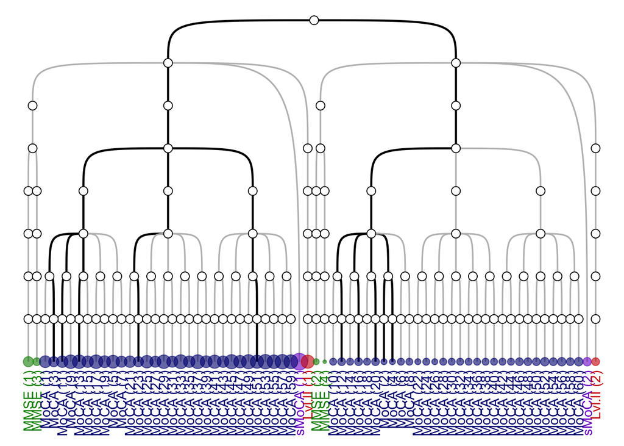

A dendrogram representing algorithms for probable Parkinson’s Disease Dementia (PDD) construction process.

```r
make_dendrogram(rates$table, approx_acc$table)
```

## Concordance between Algorithms

```r
# Dimensions of the results table:
dims <- glue::glue("{dim(conc$table)[1]} rows x {dim(conc$table)[2]} columns")

# Number of observations per algorithm pair:
obs_pairs <- conc$table |>
  count(N) |>
  drop_na() |> # NA for cases where reference == predictor
  mutate(perc = 100 * n / sum(n))

# The most missing values present:
min_miss <- glue::glue("{round(100 * (n_incl - obs_pairs[1, 'N']) / n_incl, 2)}%")

# Percentage of algorithm pairs with N > K-1
K <- 200
perc_above_k <- obs_pairs |>
  filter(N >= K) |>
  pull(perc) |>
  sum() |>
  do_summary(2)
```

Results of the analyses of prediction Accuracy, Cohen’s $\kappa$, Sensitivity and Specificity are presented in (**fig-acc?**), (**fig-kappa?**), (**fig-sens?**) and (**fig-spec?**) respectively.[^2] Generally, algorithms that employed the same operationalization of IADL deficit showed substantial pairwise concordance, however, algorithms that operationalized IADL deficit differently did not. Whereas among algorithms with identical IADL deficit operationalization, the agreement judged by Cohen’s $\kappa$ was moderately high (operationalization by FAQ total score: $\kappa$ = 0.75, SD = 0.14; operationalization by FAQ item 9: $\kappa$ = 0.86, SD = 0.09), among algorithms that differ in IADL deficit operationalization but are otherwise identical it was low: $\kappa$ = 0.43, SD = 0.08.

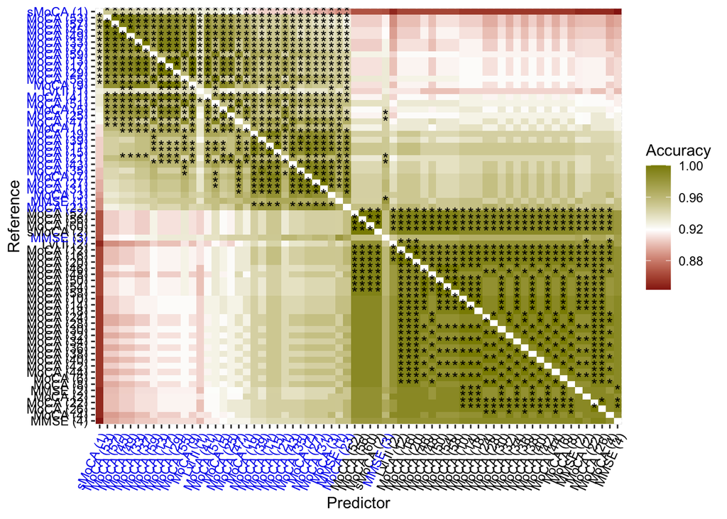

Prediction accuracy matrix.

```r
conc$plots$Accuracy
```

## Prediction of Level II Criteria

```r
lvlII_rates <- c(
  faq_tot = subset(rates$table, type == "Lvl.II (1)")$perc |>
    do_summary(2) |>
    paste0("%"),
  faq_9 = subset(rates$table, type == "Lvl.II (2)")$perc |>
    do_summary(2) |>
    paste0("%")
)

smoca_stats <- c(
  spec = subset(conc$table, predictor == "sMoCA (1)" & reference == "Lvl.II (1)")$Specificity |> do_summary(2),
  sens = subset(conc$table, predictor == "sMoCA (1)" & reference == "Lvl.II (1)")$Sensitivity |> do_summary(2)
)
```

### Descriptive Analysis

For easier interpretability of our results, we next examined cases where Level II algorithms served as a reference and Level I algorithms as a predictor. (**tbl-approx?**) shows five Level I algorithms with the highest and five with the lowest accuracy in predicting Level II classification of probable PDD. **Across IADL deficit definitions, the top five Level I algorithms were all MoCA-based and most of them defined Executive Function deficit by Clock drawing rather than the Verbal fluency test, and Language deficit by Animal naming rather than Abstraction. On the other hand, the MMSE-based criteria performed worse in predicting their respective Level II classification and ranked near the bottom.**

$$Insert Table 3 here$$

```r
approx_acc$gtable
```

| Level II (1)<sup>a</sup> Predictor | Level II (1)<sup>a</sup> κ | Level II (1)<sup>a</sup> Accuracy | Level II (1)<sup>a</sup> p | Level II (1)<sup>a</sup> Sensitivity | Level II (1)<sup>a</sup> Specificity | Level II (2)<sup>b</sup> Predictor | Level II (2)<sup>b</sup> κ | Level II (2)<sup>b</sup> Accuracy | Level II (2)<sup>b</sup> p | Level II (2)<sup>b</sup> Sensitivity | Level II (2)<sup>b</sup> Specificity |
| --- | --- | --- | --- | --- | --- | --- | --- | --- | --- | --- | --- |
| Top five |  |  |  |  |  |  |  |  |  |  |  |
| MoCA (23) | 0.62 | 0.94 | .017 | 0.50 | 0.99 | MoCA (12) | 0.85 | 0.99 | .028 | 0.86 | 0.99 |
| MoCA (3) | 0.62 | 0.94 | .017 | 0.50 | 0.99 | MoCA (16) | 0.85 | 0.99 | .028 | 0.86 | 0.99 |
| MoCA (51) | 0.69 | 0.94 | .017 | 0.70 | 0.97 | MoCA (2) | 0.83 | 0.99 | .028 | 0.71 | 1.00 |
| MoCA (11) | 0.61 | 0.94 | .032 | 0.55 | 0.98 | MoCA (20) | 0.85 | 0.99 | .028 | 0.86 | 0.99 |
| MoCA (13) | 0.67 | 0.94 | .032 | 0.70 | 0.97 | MoCA (4) | 0.83 | 0.99 | .028 | 0.71 | 1.00 |
| Bottom five |  |  |  |  |  |  |  |  |  |  |  |
| MoCA (5) | 0.59 | 0.93 | .093 | 0.60 | 0.97 | MoCA (50) | 0.70 | 0.98 | .168 | 0.71 | 0.99 |
| sMoCA (1) | 0.69 | 0.93 | .093 | 0.95 | 0.92 | MoCA (54) | 0.70 | 0.98 | .168 | 0.71 | 0.99 |
| MMSE (3) | 0.43 | 0.93 | .136 | 0.32 | 0.99 | MoCA (58) | 0.70 | 0.98 | .168 | 0.71 | 0.99 |
| MoCA (25) | 0.55 | 0.92 | .143 | 0.55 | 0.97 | MMSE (2) | 0.66 | 0.98 | .168 | 0.57 | 0.99 |
| MoCA (39) | 0.53 | 0.92 | .143 | 0.50 | 0.97 | MMSE (4) | 0.53 | 0.97 | .296 | 0.43 | 0.99 |

<sup>a</sup> IADL deficit was defined as FAQ (total score) > 7  
<sup>b</sup> IADL deficit was defined as FAQ (item 9) > 1  
κ: Cohen's κ; p: p-value associated with a one-sided Exact Binomial Test comparing the Accuracy to the No Information Rate; The table shows five most accurate (Top five) and five least accurate (Bottom five) Level I algorithms for Parkinson's Disease Dementia (PDD) in predicting Level II classificiation of PDD. The algorithms were grouped by their definition of the deficit in Instrumental Activities of Daily Living (IADLs). The items comprising each listed algorithm can be found in Table A1.

**However**, suppose the predictors are sorted by their balanced accuracy (i.e., average of sensitivity and specificity) instead of raw accuracy. In that case, the results are similar, with the exception that for the prediction of Level II with total FAQ score algorithm for probable PDD, the highest balanced accuracy was achieved by the sMoCA algorithm with sensitivity 0.95 and specificity 0.92 (see (**tbl-approx-bal?**)).

### Exploratory Varaible Selection

```r
pred_mods <- tar_read(prediction_models, store = upstore)
post_pred <- tar_read(posterior_prediction, store = upstore)
rules <- tar_read(scoring_rules, store = upstore)
```

**Comparisons of submodels’ predictive performance compared to the reference model are shown in (**fig-projpred?**). When FAQ item 9 was used to define IADL deficit, the intercept-only submodel achieved predictive performance comparable to the reference model. Given the very low PDD rate estimate of this algorithm (3.68%), no further analysis was conducted for this operationalization.**

```r
eqs <- stringr::str_remove(c(
  rules[[1]]$scoring[[1]]$integer_rule$equation,
  rules[[1]]$scoring[[5]]$integer_rule$equation
), "1.00 × ")

thres <- paste0(
  do_summary(100 * plogis(unique(rules[[1]]$threshold)), 1),
  "%"
)
```

**When FAQ total score was used to define IADL deficit, projection predictive procedure identified two submodels capable of matching the predictive performance of the reference model: one containing two predictors and another containing six predictors. Inspection of the ELPD trajectories indicated a clear improvement in predictive performance when the second predictor was added, followed by a decrease in performance for models containing three to five predictors (see (**fig-projpred?**) A–B). Moreover, because the two-predictor model already achieved good predictive performance and provided substantial greater parsimony, it was selected as the final screening model. The selected model included MoCA Five words and MMSE Sevens as indexes of probable PDD (see (**fig-projpred-rk?**) for ranking of candidate predictors’ importance).**

**The observed PDD rate according to the Level II algorithm was 10.00%. Screening model optimal decision thresholds according to the prevalence-adjusted Youden criterion are presented in (**tbl-thresh?**). These thresholds clustered according to assumed population prevalence to two groups. For assumed prevalence between 10% and 40%, the optimal threshold corresponded to a predicted PDD probability of 21.5%, yielding a decision rule characterized by high specificity and low sensitivity. Under an assumed prevalence of 50%, the optimal threshold decreased to 6.6%, yielding a decision rule characterized by high sensitivity and low specificity.**

**(**tbl-thresh?**) translates these model prediction probability thresholds into practical preliminary screening rules expressed as weighted sums of MoCA Five Words and MMSE Sevens raw scores. Moreover, (**fig-postpred?**) presents posterior predictions of the screening model for all observable combinations of its predictors values together with the corresponding decision thresholds. As evident from the figure, predictive uncertainty increases as the predicted probability of PDD rises.**

$$Insert Table 4 and Figure 3
here$$

```r
tibble::tibble(
  prev = c("0.1-0.4", "0.5"),
  thres = plogis(unique(rules[[1]]$threshold)),
  spec = unique(rules[[1]]$specificity),
  sens = unique(rules[[1]]$sensitivity),
  acc = unique(rules[[1]]$accuracy),
  eq = eqs
) |>
  gt_apa_table() |>
  fmt_number(columns = everything(), decimals = 2) |>
  fmt_number(columns = thres, decimals = 3) |>
  cols_label(
    prev ~ "Prevalence",
    thres ~ "Threshold",
    spec ~ "Specificity",
    sens ~ "Sensitivity",
    acc ~ "Accuracy",
    eq ~ "Clinical Scoring Rule"
  ) |>
  tab_source_note(html(
    "Note. Prevalence: assumed/expected prevalence of Parkinson's disease dementia (PDD); Threshold: optimal threshold of the linear prediction of the screening model on probability scale. Specificity, Sensitivity and Accuracy refer to model performance in predicting PDD according to Level II criteria in current sample. Optimal decision threshold was found using the prevalence-adjusted Youden criterion."
  ))
```

| Prevalence | Threshold | Specificity | Sensitivity | Accuracy | Clinical Scoring Rule |
| --- | --- | --- | --- | --- | --- |
| 0.1-0.4 | 0.215 | 0.98 | 0.32 | 0.91 | MoCA Five words + 1.23 × MMSE Sevens ≤ 3.07 |
| 0.5 | 0.066 | 0.41 | 1.00 | 0.47 | MoCA Five words + 1.23 × MMSE Sevens ≤ 8.41 |

Note. Prevalence: assumed/expected prevalence of Parkinson's disease dementia (PDD); Threshold: optimal threshold of the linear prediction of the screening model on probability scale. Specificity, Sensitivity and Accuracy refer to model performance in predicting PDD according to Level II criteria in current sample. Optimal decision threshold was found using the prevalence-adjusted Youden criterion.

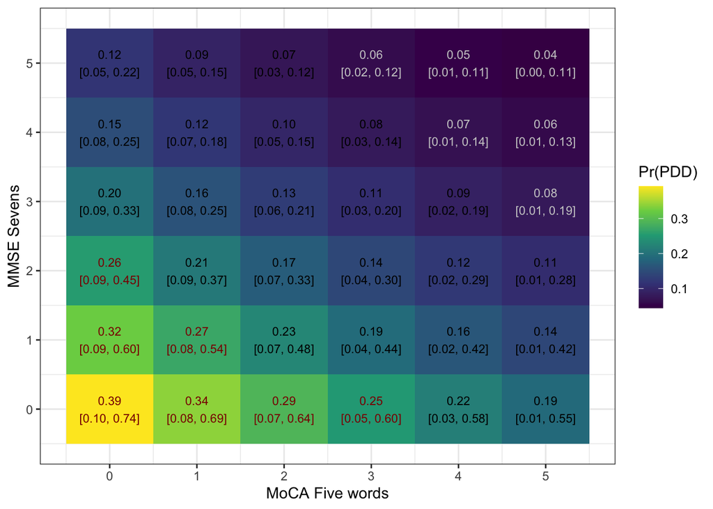

Posterior prediction and decision thresholds for probable PDD based on the selected screening model.

```r
post_pred +
  labs(x = "MoCA Five words", y = "MMSE Sevens") +
  scale_y_continuous(breaks = 0:5, labels = 0:5) +
  scale_x_continuous(breaks = 0:5, labels = 0:5)
```

# Discussion

This study systematically investigated the application of multiple Level I diagnostic **algorithms for probable PDD and evaluated their predictive validity with respect to Level II classification**. Our results show variability in PDD rate estimates, strongly influenced by the choice of cognitive screening instrument (MMSE, MoCA and sMoCA) and the operationalization of functional impairment. The divergence observed across algorithms demonstrates the sensitivity of diagnostic outcomes to seemingly negligible methodological choices. **Predictive validity analyses further indicated that MoCA-based algorithms outperform MMSE-based algorithms and yielded a preliminary two-item screening heuristic that may assist early identification of probable PDD during DBS candidacy evaluation.**

## Variability in PDD Rate Estimates

```r
rate_min <- sub("-.*", "", rates_overall["minmax"])
rate_max <- sub(".*-", "", rates_overall["minmax"])
```

Our results showed a wide range in estimated PDD rate across algorithms, ranging from 2.11% to 16.84%. Estimates reached lower rates when using solely FAQ item 9 (as an approximation of the pill questionnaire suggested by Dubois et al. (2007)) in comparison with the full FAQ scale. This discrepancy highlights the diagnostic importance of how IADLs are assessed.

Our overall PDD rates were consistently lower than previous studies regarding dementia among PD patients, demonstrating wide variability based on various criteria used. For instance, a retrospective study reported a PDD rate of 19.7% (Rana et al. 2011), while other clinical investigations found even higher rate, reaching up to 30% (Aarsland, Zaccai, and Brayne 2005). A recent meta-analysis synthesizing global data placed the expected PDD rate in PD at 26.30% (Sousa et al. 2022). Compared to these estimates, our study reports generally lower PDD rates, likely reflecting differences in diagnostic criteria, methodology and sample characteristics. Specifically, our sample was younger compared to other PD cohorts and age was repeatedly shown to be a strong predictor of PDD across studies (Rana et al. 2011; Sousa et al. 2022).

```r
over70 <- data |>
  mutate(older = 100 * (age >= 70)) |>
  pull(older) |>
  mean(na.rm = TRUE) |>
  round(1) |>
  paste0("%")
```

Interestingly, we did not observe any reliable age-related differences in PDD rate within our cohort. This lack of age-dependency may, however, also stem from the relatively younger age of our cohort, because previous reports indicate that the association between age and PDD is not linear but increases with age and may not reach substantial values before older age. In both Rana et al. (2011) and Oh et al. (2016), nine out of ten patients with dementia were 70 years of age or older. In our sample, only 4.2% participants were in this age range. Consequently, studies with older cohorts are probably necessary to detect a robust association between age and the risk of probable PDD.

## Concordance Between Diagnostic Algorithms

Pairwise comparisons of diagnostic algorithms showed that agreement was notably stronger among those using the same IADL operationalization compared to those using different IADL definitions. Moreover, the agreement was slightly higher between algorithms that defined IADL deficit by FAQ item 9 compared to algorithms that defined it using the full FAQ scale. One possible explanation of this difference follows from the observation that algorithms using the full-scale definition yielded higher PDD rate estimates. Because there was a higher probability of being diagnosed with IADL deficit based on the full FAQ scale, there was also a bigger room for disagreement in the cognitive impairment status when different indexes were used (e.g. by defining executive deficit via Clock Drawing vs. Verbal Fluency).

## Predictive Validity Comparison With Level II Criteria

Using Level II diagnosis as the gold standard, MoCA-based Level I algorithms, particularly those using Clock Drawing to assess executive function, demonstrated the highest predictive accuracy. This supports recent proposals to modernize PDD diagnostic frameworks (Kulisevsky et al. 2024), favoring MoCA-derived components and more ADL-specific, PD-tailored functional assessment tools. In contrast, MMSE-based algorithms consistently underperformed, suggesting limited sensitivity in capturing cognitive deficits typical in PDD.

Furthermore, in the algorithm using sMoCA, the raw accuracy was moderate, however, the balanced accuracy (i.e. combined sensitivity and specificity) was high. Consequently, sMoCA appears particularly suitable for approximating Level II PDD diagnosis in populations that differ in PDD prevalence from our cohort, since balanced accuracy, unlike raw accuracy, is independent of prevalence in the sample. Moreover, because the sMoCA algorithm demonstrated higher sensitivity while maintaining comparable specificity (see (**tbl-approx-bal?**)), it may be especially valuable in contexts where false negatives carry substantial clinical cost. In such cases, a neuropsychologist might use sMoCA as an initial screening tool and proceed to a full Level II assessment only for patients who meet criteria for probable PDD in this preliminary stage.

**A further opportunity for simplifying screening was explored by means of a variable selection analysis. When functional impairment was defined using the FAQ total score, a weighted combination of the MoCA Five Words and MMSE Sevens items predicted Level II PDD classification with accuracy comparable to a model including all screening indexes. Because the projection-predictive framework is designed to identify minimal predictive subsets while controlling for overfitting (Piironen and Vehtari 2017a; Piironen, Paasiniemi, and Vehtari 2020), these findings suggest that a highly parsimonious screening heuristic may be feasible in DBS candidate cohorts. The resulting decision thresholds and posterior predictions are presented in (**tbl-thresh?**) and (**fig-postpred?**).**

**The variable selection analysis also highlights a practival trade-off between sensitivity and specificity that depends on the assumed prevalence of PDD in the screened population. In practice, clinicians using brief screening tools may need to prioritize either minimizing false negatives or limiting unnecessary follow-up assessments. While adding additional screening indexes could improve classification performance, this would increase the complexity and time demands of the screening procedure. Our results suggest that items such as MMSE Pentagons, MoCA Animal Naming, or MoCA Abstraction may represent promising candidates for expanding such parsimonious screening models in DBS candidate cohorts (see (**fig-projpred-rk?**)).**

**The two items selected for our screening model, MoCA Five Words and MMSE Sevens, may reflect the importance of a fronto-striatal executive deficit in PDD classification within our cohort. Although MoCA Five Words is typically interpreted as a memory measure, it is like to place greater executive demand than the its equivalent in MMSE, the three words task. Indeed, normative data suggest that MoCA Five Words is the most difficult item of MoCA in Czech neurologically healthy individuals (Ondrej Bezdicek et al. 2024). Because this item difficulty may partly reflect the longer retention interval rather than executive demands alone, future studies should examine whether the predictive performance of these items persists when administered outside the full MoCA context.**

**This pattern is consistent with l**ongitudinal cohort studies **evidence suggest**ing** that patients considered for DBS represent a subset of the PD population with a distinct cognitive phenotype (Bove et al. 2020; Mana et al. 2024). Specifically, findings of gradual post-surgical cognitive decline predicted by pre-surgical executive deficits indicate that DBS candidates may be preferentially drawn from a fronto-striatal phenotype characterized by slowly progressing executive dysfunction, rather than from a posterior phenotype marked by visuospatial impairment (Kehagia, Barker, and Robbins 2012). Importantly, patients with the posterior phenotype may be at greater risk of developing PDD within as little as five years after disease onset (Williams-Gray et al. 2009; Summers et al. 2024).

## Constraints on Generality

This study’s generalizability is limited by the homogeneity of the patient cohort, which does not reflect the diversity of cognitive profiles seen in broader PD populations. Specifically, the younger age of the sample, and a possible underrepresentation of high-risk phenotypes for PDD constrain the generality of the presented findings.

As noted above, the younger age of our sample may partly explain the lower rate of PDD observed compared to previous studies. As discussed in the *Theoretical and Empirical Estimands* section, neither estimates of PDD rate nor predictive performance of demographic variables therefore should not be generalized beyond PD patients who are DBS candidates. The extent to which our findings on the concordance between diagnostic algorithms apply to the broader PD population remains to be determined in future studies using different types of cohorts, such as de novo patients or community-based samples.

In our study, visuospatial function was assessed uniformly across all algorithms within a given screening measure (MoCA cube or MMSE pentagons). By contrast, we compared two operationalizations of executive dysfunction, the clock drawing test and verbal fluency. The clock drawing test showed stronger predictive value for level II diagnosis than verbal fluency, suggesting that even within our cohort, patients who developed PDD may exhibit features of the posterior phenotype.

However, the use of a DBS cohort also offered several methodological advantages. All patients underwent standardized and comprehensive neuropsychological testing, resulting in a well-characterized dataset that enabled a systematic evaluation of multiple diagnostic algorithms. Moreover, because dementia is a common exclusion criterion for DBS treatment (Bronstein et al. 2011), examining the diagnostic accuracy of algorithms for PDD in a pre-DBS cohort is informative in its own right. **Moreover, as discussed in the *Theoretical and Empirical Estimands* section, discrepancies in PDD rate estimates arising from alternative definitions of IADL impairment have implications for the construct validity of the diagnostic criteria themselves. If algorithms intended to operationalize the same construct yield divergent classifications when applied to the same patients, this suggests that the construct is not consistently captured by its operational definitions. Such discrepancies therefore inform the validity of PDD diagnostic frameworks beyond the specific sample studied.**

## Limitations and Future Directions

Due to the retrospective nature of the study, some patients lacked one or more key measures required for the diagnosis of probable PDD by certain algorithms. Missing data were handled using the complete cases method. **Although this approach reduces statistical power, it ensures that comparisons between diagnostic algorithms are performed on identical patient subsets, thereby minimizing bias due to sample heterogeneity across pairwise analyses.**

An additional limitation concerns the use of the FAQ questionnaire for IADL assessment. The FAQ is a subjective or informant-reliant measure and thus susceptible to bias. Moreover, its content can vary across sociocultural contexts, which limits its cross-cultural transferability. For example, activities such as financial management, cooking or driving, are not universally practiced across societies. Consequently, both the FAQ scores and diagnostic thresholds used to indicate IADL impairment may not be directly transferable between cultural settings (O’Donald and Calia 2025). These factors may influence both the sensitivity and ecological validity of the functional criteria used (O. Bezdicek, Lukavský, and Preiss 2011; Ondrej Bezdicek, Stepankova, et al. 2016).

Furthermore, IADL measures may correlate with neuropsychological results of specific cognitive domains, particularly attention/processing speed, and executive function (Reppermund et al. 2011; Moheb et al. 2017). If such correlations were due to shared error variance, they could bias concordance indices measured in this study. To examine this possibility, we conducted a post-hoc simulation experiment, available at https://josefmana.github.io/demcrit/articles/correlation.html. The results indicated that correlations between IADL and neuropsychological measures may either increase or decrease accuracy and balanced accuracy, while consistently inflating Cohen’s $\kappa$ estimates. However, given the correlations observed in our dataset, the effect size was small and unlikely to alter the conclusions of our study.

To address concerns about measuring IADL outlined above, future research should consider using PD-specific questionnaires or more objective tools. Promising options include the Penn Parkinson’s Daily Activities Questionnaire-15 (Brennan et al. 2016), questionnaire adaptations including items regarding gadget use and digital literacy (Postema et al. 2024) or performance-based assessments (Schmitter-Edgecombe et al. 2020). Our findings underscore the importance of IADL measurement for the PDD diagnosis. Therefore, we recommend exploring more reliable tools with high ecological validity.

**Another limitation stems from the specific subpopulation studied, patient undergoing evaluation for DBS. As discussed above, this group differs from the broader PD population in several important aspect including age distribution and cognitive phenotype. Consequently, neither the estimated PDD rates nor the heuristic screening model derived in this study should be generalized to the broader PD population without further validation. Larger and more heterogenous cohorts would be required to enable approaches such as post-stratification (**2022?**)to overcome this limitation.**

Finally, whereas our study systematically investigated how varying definitions of global deficit, impaired cognition and IADL deficit affect probable PDD classification, it did not explore associations of PDD diagnosis with its neuropsychiatric (e.g. anxiety profile) and biomarker correlates. Instead, we only ensured the absence of acute or severe psychiatric symptoms that would preclude a diagnosis of probable PDD, as verified through assessment by a trained neuropsychiatrist. However, both the current diagnostic criteria for PDD (Dubois et al. 2007) and recent proposals for their revision (Kulisevsky et al. 2024) emphasize the use of standardized psychometric instruments for assessing neuropsychiatric symptoms. Incorporating such measures could enhance both the efficiency and transparency of the diagnostic process. Future research should therefore investigate how integrating structured neuropsychiatric assessments and biomarker data may refine PDD diagnostic accuracy and improve clinical utility.

# Conclusions

In sum, our study **demonstrates that probable PDD classification based on Level I criteria varies substantially depending on how impaired cognition and functional decline are operationalized. In particular, the choise of** IADL **impairment definition** and cognitive screening tool **strongly influences diagnostic outcomes**. Conservative criteria, such as reliance on pill questionnaire (i.e. FAQ item 9 equivalence), may fail to detect functional decline and thus under-identify true cases of PDD. Importantly, concordance across algorithms rises significantly, reaching moderate to high values, when the same definition of IADL is used (either FAQ total or FAQ item 9). The findings support the call for a change of the current diagnostic criteria (Kulisevsky et al. 2024), favoring the use of MoCA-based components and comprehensive IADL assessments.

**Within DBS candidate cohorts, Level II classification may be approximated using a highly parsimonious screening combination of MoCA Five Words and MMSE Sevens, although this approach necessarily involves a trade-off between sensitivity and specificity. Future studies should replicate these findings in larger and more diverse PD cohorts and further examine how alternative operationalizations of other diagnostic components, including neuropsychiatric symptoms, affect PDD classification and concordance between algorithms.** To make this process easier, the code used to generate our results is publicly available and easily applicable to similarly structured data.

# Appendix

## Derivation of the Algorithms Set

Both, the original PDD criteria (Dubois et al. 2007) and the call for their change (Kulisevsky et al. 2024) allow for several distinct combinations of items to be used to define cognitive impairment. Consequently, in this study we derived all algorithms for probable PDD on Level I that are in line with published criteria. This procedure parallel the diagnostic algorithm outlined in Table 2 of Dubois et al. (2007). Specifically, in this study, we varied the exact specification of items 3-5 of this table (i.e., the measure of global cognitive impairment, the measure of the impact on IADLs and the measures of impaired cognition).

For each set of criteria (MMSE-based, MoCA-based, sMoCA-based and Level II), we first specified the items and then the thresholds for each item used to define probable PDD. If more than one option was present in either the choice of the item or the choice of the threshold, we created an algorithm for each choice in turn. The final set of algorithms was arrived at by computing the Cartesian product of all possibilities provided by varying items and thresholds. All combinations are presented in (**tbl-algos?**).

For MMSE-based algorithms, the following sets of items served as the basis:

$Global = \{MMSE < 26\}$

$Attention = \{{Sevens\ backwards < 4}\}$

$Executive = \{{Clock\ drawing} < 2, {Lexical\ fluency\ (S)} < 10\}$

$Construction = \{Pentagons < 1\}$

$Memory = \{{Three{\text-}words\ recall} < 3\}$

$IADL = \{FAQ > 7, {FAQ\ (it. 9)} > 1\}$

The ensuing Cartesian product $Global \times Attention \times Executive \times Construction \times Memory \times IADL$ results in $1 \times 1 \times 2 \times 1 \times 1 \times 2 = 4$ MMSE-based algorithms for probable PDD.

For MoCA-based algorithms, the following sets of items served as the basis:

$Global = \{MoCA < 26\}$

$Attention = \{{Sevens\ backwards < 3}\}$

$Executive = \{{Clock\ drawing} < 2, {Clock\ drawing} < 3, {Lexical\ fluency\ (K)} < 11\}$

$Construction = \{Cube\ drawing < 1\}$

$Memory = \{Five{\text-}words\ recall < 1, Five{\text-}words\ recall < 2, Five{\text-}words\ recall < 3, Five{\text-}words\ recall < 4, Five{\text-}words\ recall < 5\}$

$Language = \{Abstraction < 2, Animal\ naming < 3\}$

$IADL = \{FAQ > 7, {FAQ\ (it. 9)} > 1\}$

Note that the additional language domain adds complexity to establishing a diagnostic algorithm because simply by adding it to the set of items, the number of potential algorithms doubles. Further complexity is added by the fact that there are so far no guidelines for selecting a diagnostic threshold for Clock drawing and Five-words recall tests, both of which differ from their counterparts used by Dubois et al. (2007). Finally, although the Sevens backwards item has different thresholds in MoCA-based compared to MMSE-based algorithms, this difference is solely due to a difference in scoring whereby 3 points in MoCA correspond to 4 or 5 points in MMSE. The Seven backwards item threshold for MoCA-based algorithms used in this study is thus equivalent to its MMSE-based counterpart.

Computing the Cartesian product $Global \times Attention \times Executive \times Construction \times Memory \times Language \times IADL$ yields $1 \times 1 \times 3 \times 1 \times 5 \times 2 \times 2 = 60$ distinct MoCA-based algorithms for probable PDD.

For sMoCA-based algorithms, the following sets of items served as the basis:

$Global = \{sMoCA < 13\}$

$IADL = \{FAQ > 7, {FAQ\ (it. 9)} > 1\}$

yielding $Global \times IADL$, i.e., $1 \times 2 = 2$ distinct sMoCA-based algorithms for probable PDD.

Finally, the Level II algorithms were based on the following sets of items:

$Attention = \{z(\textit{TMT-A}) < -1.5\ \cup z(WAIS\ DSB) < -1.5\}$

$Executive = \{z(CF\ A) < -1.5\ \cup z(\textit{PST-C}) < -1.5\}$

$Construction = \{z(JoL) < -1.5\ \cup z(\textit{CLOX-I}) < -1.5\}$

$Memory = \{z(\textit{RAVLT-DR}) < -1.5\ \cup z(\textit{BVMTR- DR}) < -1.5\ \cup z(WMS\text-III\ Family\ Pictures) < -1.5\}$

$Language = \{z(WAIS\ Similarities) < -1.5 \ \cup z(\textit{BNT-60}) < -1.5\}$

$IADL = \{FAQ > 7, {FAQ\ (it. 9)} > 1\}$

where $z()$ denotes calculation of age, sex and education adjusted z-score. This yields $1 \times 1 \times 1 \times 1 \times 1 \times 2 = 2$ distinct Level II algorithms for probable PDD in the current study. All but the BNT 60 item were evaluated using regression norms published by Ondrej Bezdicek et al. (2017). Since the original article used BNT 30 instead of BNT 60, we approximated the deficit in BNT 60 by comparing patients’ raw score to age- and education-specific normative values reported by Zemanová et al. (2016). Specifically, patients whose BNT 60 score fell below 5<sup>th</sup> percentile of their demographic group in Table 6 of Zemanová et al. (2016) were considered to show signs of impaired performance.

### Operationalization of Impaired Cognition

```r
rates$gtables$algorithms
```

| Algorithm | Global deficit | Impaired cognition Attention | Impaired cognition Executive function | Impaired cognition Construction | Impaired cognition Memory | Impaired cognition Language | Impact on IADLs |  |
| --- | --- | --- | --- | --- | --- | --- | --- | --- |
| Lvl.II (1) | - | TMT A < -1.5 OR WAIS DS < -1.5 | CF A < -1.5 OR PST C < -1.5 | JoLO < -1.5 OR CLOXI < -1.5 | RAVLT-DR < -1.5 OR BVMTR-DR < -1.5 OR WMS-III Family Pictures < -1.5 | WAIS Similarities < -1.5 OR BNT 60 < -1.5 |  | FAQ > 7 |
| Lvl.II (2) | - | TMT A < -1.5 OR WAIS DS < -1.5 | CF A < -1.5 OR PST C < -1.5 | JoLO < -1.5 OR CLOXI < -1.5 | RAVLT-DR < -1.5 OR BVMTR-DR < -1.5 OR WMS-III Family Pictures < -1.5 | WAIS Similarities < -1.5 OR BNT 60 < -1.5 | FAQ 9 > 1 |  |
| MMSE (1) | Total score < 26 | Sevens < 4 | Clock Drawing < 2 | Pentagons < 1 | Three words < 3 | - | FAQ > 7 |  |
| MMSE (2) | Total score < 26 | Sevens < 4 | Clock Drawing < 2 | Pentagons < 1 | Three words < 3 | - | FAQ 9 > 1 |  |
| MMSE (3) | Total score < 26 | Sevens < 4 | VF S < 10 | Pentagons < 1 | Three words < 3 | - | FAQ > 7 |  |
| MMSE (4) | Total score < 26 | Sevens < 4 | VF S < 10 | Pentagons < 1 | Three words < 3 | - | FAQ 9 > 1 |  |
| MoCA (1) | Total score < 26 | Sevens < 3 | Clock drawing < 2 | Cube drawing < 1 | Five words < 1 | Abstraction < 2 | FAQ > 7 |  |
| MoCA (10) | Total score < 26 | Sevens < 3 | Clock drawing < 2 | Cube drawing < 1 | Five words < 3 | Abstraction < 2 | FAQ 9 > 1 |  |
| MoCA (11) | Total score < 26 | Sevens < 3 | Clock drawing < 2 | Cube drawing < 1 | Five words < 3 | Animal naming < 3 | FAQ > 7 |  |
| MoCA (12) | Total score < 26 | Sevens < 3 | Clock drawing < 2 | Cube drawing < 1 | Five words < 3 | Animal naming < 3 | FAQ 9 > 1 |  |
| MoCA (13) | Total score < 26 | Sevens < 3 | Clock drawing < 2 | Cube drawing < 1 | Five words < 4 | Abstraction < 2 | FAQ > 7 |  |
| MoCA (14) | Total score < 26 | Sevens < 3 | Clock drawing < 2 | Cube drawing < 1 | Five words < 4 | Abstraction < 2 | FAQ 9 > 1 |  |
| MoCA (15) | Total score < 26 | Sevens < 3 | Clock drawing < 2 | Cube drawing < 1 | Five words < 4 | Animal naming < 3 | FAQ > 7 |  |
| MoCA (16) | Total score < 26 | Sevens < 3 | Clock drawing < 2 | Cube drawing < 1 | Five words < 4 | Animal naming < 3 | FAQ 9 > 1 |  |
| MoCA (17) | Total score < 26 | Sevens < 3 | Clock drawing < 2 | Cube drawing < 1 | Five words < 5 | Abstraction < 2 | FAQ > 7 |  |
| MoCA (18) | Total score < 26 | Sevens < 3 | Clock drawing < 2 | Cube drawing < 1 | Five words < 5 | Abstraction < 2 | FAQ 9 > 1 |  |
| MoCA (19) | Total score < 26 | Sevens < 3 | Clock drawing < 2 | Cube drawing < 1 | Five words < 5 | Animal naming < 3 | FAQ > 7 |  |
| MoCA (2) | Total score < 26 | Sevens < 3 | Clock drawing < 2 | Cube drawing < 1 | Five words < 1 | Abstraction < 2 | FAQ 9 > 1 |  |
| MoCA (20) | Total score < 26 | Sevens < 3 | Clock drawing < 2 | Cube drawing < 1 | Five words < 5 | Animal naming < 3 | FAQ 9 > 1 |  |
| MoCA (21) | Total score < 26 | Sevens < 3 | VF K < 11 | Cube drawing < 1 | Five words < 1 | Abstraction < 2 | FAQ > 7 |  |
| MoCA (22) | Total score < 26 | Sevens < 3 | VF K < 11 | Cube drawing < 1 | Five words < 1 | Abstraction < 2 | FAQ 9 > 1 |  |
| MoCA (23) | Total score < 26 | Sevens < 3 | VF K < 11 | Cube drawing < 1 | Five words < 1 | Animal naming < 3 | FAQ > 7 |  |
| MoCA (24) | Total score < 26 | Sevens < 3 | VF K < 11 | Cube drawing < 1 | Five words < 1 | Animal naming < 3 | FAQ 9 > 1 |  |
| MoCA (25) | Total score < 26 | Sevens < 3 | VF K < 11 | Cube drawing < 1 | Five words < 2 | Abstraction < 2 | FAQ > 7 |  |
| MoCA (26) | Total score < 26 | Sevens < 3 | VF K < 11 | Cube drawing < 1 | Five words < 2 | Abstraction < 2 | FAQ 9 > 1 |  |
| MoCA (27) | Total score < 26 | Sevens < 3 | VF K < 11 | Cube drawing < 1 | Five words < 2 | Animal naming < 3 | FAQ > 7 |  |
| MoCA (28) | Total score < 26 | Sevens < 3 | VF K < 11 | Cube drawing < 1 | Five words < 2 | Animal naming < 3 | FAQ 9 > 1 |  |
| MoCA (29) | Total score < 26 | Sevens < 3 | VF K < 11 | Cube drawing < 1 | Five words < 3 | Abstraction < 2 | FAQ > 7 |  |
| MoCA (3) | Total score < 26 | Sevens < 3 | Clock drawing < 2 | Cube drawing < 1 | Five words < 1 | Animal naming < 3 | FAQ > 7 |  |
| MoCA (30) | Total score < 26 | Sevens < 3 | VF K < 11 | Cube drawing < 1 | Five words < 3 | Abstraction < 2 | FAQ 9 > 1 |  |
| MoCA (31) | Total score < 26 | Sevens < 3 | VF K < 11 | Cube drawing < 1 | Five words < 3 | Animal naming < 3 | FAQ > 7 |  |
| MoCA (32) | Total score < 26 | Sevens < 3 | VF K < 11 | Cube drawing < 1 | Five words < 3 | Animal naming < 3 | FAQ 9 > 1 |  |
| MoCA (33) | Total score < 26 | Sevens < 3 | VF K < 11 | Cube drawing < 1 | Five words < 4 | Abstraction < 2 | FAQ > 7 |  |
| MoCA (34) | Total score < 26 | Sevens < 3 | VF K < 11 | Cube drawing < 1 | Five words < 4 | Abstraction < 2 | FAQ 9 > 1 |  |
| MoCA (35) | Total score < 26 | Sevens < 3 | VF K < 11 | Cube drawing < 1 | Five words < 4 | Animal naming < 3 | FAQ > 7 |  |
| MoCA (36) | Total score < 26 | Sevens < 3 | VF K < 11 | Cube drawing < 1 | Five words < 4 | Animal naming < 3 | FAQ 9 > 1 |  |
| MoCA (37) | Total score < 26 | Sevens < 3 | VF K < 11 | Cube drawing < 1 | Five words < 5 | Abstraction < 2 | FAQ > 7 |  |
| MoCA (38) | Total score < 26 | Sevens < 3 | VF K < 11 | Cube drawing < 1 | Five words < 5 | Abstraction < 2 | FAQ 9 > 1 |  |
| MoCA (39) | Total score < 26 | Sevens < 3 | VF K < 11 | Cube drawing < 1 | Five words < 5 | Animal naming < 3 | FAQ > 7 |  |
| MoCA (4) | Total score < 26 | Sevens < 3 | Clock drawing < 2 | Cube drawing < 1 | Five words < 1 | Animal naming < 3 | FAQ 9 > 1 |  |
| MoCA (40) | Total score < 26 | Sevens < 3 | VF K < 11 | Cube drawing < 1 | Five words < 5 | Animal naming < 3 | FAQ 9 > 1 |  |
| MoCA (41) | Total score < 26 | Sevens < 3 | Clock drawing < 3 | Cube drawing < 1 | Five words < 1 | Abstraction < 2 | FAQ > 7 |  |
| MoCA (42) | Total score < 26 | Sevens < 3 | Clock drawing < 3 | Cube drawing < 1 | Five words < 1 | Abstraction < 2 | FAQ 9 > 1 |  |
| MoCA (43) | Total score < 26 | Sevens < 3 | Clock drawing < 3 | Cube drawing < 1 | Five words < 1 | Animal naming < 3 | FAQ > 7 |  |
| MoCA (44) | Total score < 26 | Sevens < 3 | Clock drawing < 3 | Cube drawing < 1 | Five words < 1 | Animal naming < 3 | FAQ 9 > 1 |  |
| MoCA (45) | Total score < 26 | Sevens < 3 | Clock drawing < 3 | Cube drawing < 1 | Five words < 2 | Abstraction < 2 | FAQ > 7 |  |
| MoCA (46) | Total score < 26 | Sevens < 3 | Clock drawing < 3 | Cube drawing < 1 | Five words < 2 | Abstraction < 2 | FAQ 9 > 1 |  |
| MoCA (47) | Total score < 26 | Sevens < 3 | Clock drawing < 3 | Cube drawing < 1 | Five words < 2 | Animal naming < 3 | FAQ > 7 |  |
| MoCA (48) | Total score < 26 | Sevens < 3 | Clock drawing < 3 | Cube drawing < 1 | Five words < 2 | Animal naming < 3 | FAQ 9 > 1 |  |
| MoCA (49) | Total score < 26 | Sevens < 3 | Clock drawing < 3 | Cube drawing < 1 | Five words < 3 | Abstraction < 2 | FAQ > 7 |  |
| MoCA (5) | Total score < 26 | Sevens < 3 | Clock drawing < 2 | Cube drawing < 1 | Five words < 2 | Abstraction < 2 | FAQ > 7 |  |
| MoCA (50) | Total score < 26 | Sevens < 3 | Clock drawing < 3 | Cube drawing < 1 | Five words < 3 | Abstraction < 2 | FAQ 9 > 1 |  |
| MoCA (51) | Total score < 26 | Sevens < 3 | Clock drawing < 3 | Cube drawing < 1 | Five words < 3 | Animal naming < 3 | FAQ > 7 |  |
| MoCA (52) | Total score < 26 | Sevens < 3 | Clock drawing < 3 | Cube drawing < 1 | Five words < 3 | Animal naming < 3 | FAQ 9 > 1 |  |
| MoCA (53) | Total score < 26 | Sevens < 3 | Clock drawing < 3 | Cube drawing < 1 | Five words < 4 | Abstraction < 2 | FAQ > 7 |  |
| MoCA (54) | Total score < 26 | Sevens < 3 | Clock drawing < 3 | Cube drawing < 1 | Five words < 4 | Abstraction < 2 | FAQ 9 > 1 |  |
| MoCA (55) | Total score < 26 | Sevens < 3 | Clock drawing < 3 | Cube drawing < 1 | Five words < 4 | Animal naming < 3 | FAQ > 7 |  |
| MoCA (56) | Total score < 26 | Sevens < 3 | Clock drawing < 3 | Cube drawing < 1 | Five words < 4 | Animal naming < 3 | FAQ 9 > 1 |  |
| MoCA (57) | Total score < 26 | Sevens < 3 | Clock drawing < 3 | Cube drawing < 1 | Five words < 5 | Abstraction < 2 | FAQ > 7 |  |
| MoCA (58) | Total score < 26 | Sevens < 3 | Clock drawing < 3 | Cube drawing < 1 | Five words < 5 | Abstraction < 2 | FAQ 9 > 1 |  |
| MoCA (59) | Total score < 26 | Sevens < 3 | Clock drawing < 3 | Cube drawing < 1 | Five words < 5 | Animal naming < 3 | FAQ > 7 |  |
| MoCA (6) | Total score < 26 | Sevens < 3 | Clock drawing < 2 | Cube drawing < 1 | Five words < 2 | Abstraction < 2 | FAQ 9 > 1 |  |
| MoCA (60) | Total score < 26 | Sevens < 3 | Clock drawing < 3 | Cube drawing < 1 | Five words < 5 | Animal naming < 3 | FAQ 9 > 1 |  |
| MoCA (7) | Total score < 26 | Sevens < 3 | Clock drawing < 2 | Cube drawing < 1 | Five words < 2 | Animal naming < 3 | FAQ > 7 |  |
| MoCA (8) | Total score < 26 | Sevens < 3 | Clock drawing < 2 | Cube drawing < 1 | Five words < 2 | Animal naming < 3 | FAQ 9 > 1 |  |
| MoCA (9) | Total score < 26 | Sevens < 3 | Clock drawing < 2 | Cube drawing < 1 | Five words < 3 | Abstraction < 2 | FAQ > 7 |  |
| sMoCA (1) | sMoCA total score < 13 | - | - | - | - | - | FAQ > 7 |  |
| sMoCA (2) | sMoCA total score < 13 | - | - | - | - | - | FAQ 9 > 1 |  |

*Note.* UPDRS III off state: Unified Parkinson’s Disease Rating Scale Part III, Off medication, UPDRS III on state: Unified Parkinson’s Disease Rating Scale Part III, On medication, BDI-II: Beck Depression Inventory, STAI X1: State Trait-Anxiety Inventory (STAI), Part 1 (state anxiety), STAI X2: STAI, Part 2 (trait anxiety), FAQ: Functional Assessment Questionnaire, FAQ 9: Functional Assessment Questionnaire, Item 9, DRS-II: Dementia Rating Scale Second Edition, NART: National Adult Reading Test, TMT-A: Trail Making Test, Part A, WAIS DSB: Wechsler Adult Intelligence Scale Digit Span, Backwards, CF-A: Categorical Verbal Fluency, Animals, PST-C: Prague Stroop Test, Colours, WAIS Similarities: Wechsler Adult Intelligence Scale, Similarities, BNT-60: Boston Naming Test, RAVLT-DR: Rey Auditory Verbal Learning Test, Delayed Recall, BVMTR-DR: Brief Verbal Memory Test, Delayed Recall, WMS-III Family Pictures: Wechsler Memory Scale Family Pictures, JoL: Boston Judgement of Line Orientation, CLOX-I: Clock Drawing Test

## Theoretical and Empirical Estimands Elaborated

In this study, we follow the framework proposed by Lundberg, Johnson, and Stewart (2021) for specifying targets of inference (i.e., the estimands) in quantitative sciences to increase transparency and connect statistical evidence to relevant theory. (**tbl-estimands?**) contains verbal description of the components relating to each of our proclaimed research objectives and map them to the population quantity of interest (the theoretical estimand), data-dependent quantity that could be estimated (the empirical estimand) and quantities that are reported in the study (statistical estimates).

```r
table_estimands()
```

|  | Theoretical Estimand Quantity | Theoretical Estimand Population | Empirical Estimand | Statistical Estimate |  |  |
| --- | --- | --- | --- | --- | --- | --- |
| Research Objective 1 |  |  |  |  |  |  |
| To estimate the rate of PDD within PD. | The true rate of PDD within the population of patients with PD. | DBS candidates with PD |  |  | Proportion of patients classified as having probable PDD according to each of the algorithms under consideration. | Measures of central tendency (mean, median) of the proportion of patients with probable PDD in the sample across algorithms under consideration. |
| To assess variability of PDD diagnosis depending on the algorithm applied. | The variance of PDD rate estimates attributable to the diagnostic process itself, i.e., the extent to which different algorithms for probable PDD yield differing PDD rate estimates for the same popula… | DBS candidates with PD | Shape of the distribution of probable PDD rate according to each of the algorithms under consideration. | Measures of variability (standard deviation, range) of the proportion of patients with probable PDD in the sample across algorithms under consideration. |  |  |
| To evaluate predictive information provided by demographic variables for probable PDD diagnosis. | The expected change of suffering with PDD given a unit change in age or sex. | DBS candidates with PD | Estimates of expected change in the expected value of the probability of PDD given a change in age or sex for each of the algorithms under consideration. | A set of transformed logistic regression coefficients (Odds Ratios) for age, sex and their statistical interaction for each of the algorithms under consideration. |  |  |
| To evaluate the diagnostic concordance between different PDD algorithms within and between PDD criteria. | A set of population-level contingency tables comparing probable PDD classification assigned by each pair of probable PDD algorithms, along with derived metrics such as sensitivity, specificity, and in… | General population of patients with PD | Matrices generated by pairwise Receiver Operating Characteristic (ROC) curve analyses that evaluate the discriminatory performance of each probable PDD algorithm. | Metrics derived from pairwise ROC analyses - Cohen's Kappa, Sensitivity, Specificity, Accuracy and statistical comparison between Accuracy and No Information Rate (NIR). |  |  |
| Research Objective 2 |  |  |  |  |  |  |
| To identify algorithms' components that contribute to variability in probable PDD diagnosis within and across criteria. | A set of algorithms' components (such as diagnostic thresholds or test indexes being used to measure a certain cognitive domain) whose variation systematically alters the probability of a probable PDD… | General population of patients with PD | Changes in the proportion of probable PDD induced by varying sets of algorithms components. | Visually inspected differences in probable PDD rate distributions conditional on sets of algorithms' components. |  |  |
| Research Objective 3 |  |  |  |  |  |  |
| To evaluate the diagnostic concordance between Level I and Level II PDD algorithms. | A set of Level I probable PDD algorithms, ranked by the accuracy in predicting Level II PDD classification. | DBS candidates with PD | Level I probable PDD algorithms ranking based on their accuracy of prediction PDD classification on Level II in the sample. | Ranking of the available algorithms for probable PDD |  |  |
| To identify minimal set of screening indexes that well approximate Level II PDD classification. | Classification model of Level II PDD classification given a few screening indexes from Level I. | DBS candidates with PD | Logistic regression model with reduced prediction set based on projective prediction on a reference model containing all available candidate predictors. | A set of optimal decision equation based on ROC analysis under different assumed real PDD prevalences. |  |  |

The RO1 - to estimate the PDD rate and evaluate the diagnostic variability and concordance across different algorithms of probable PDD - was divided into four distinct research objectives:

- to estimate the rate of PDD within PD (RO1.1),
- to estimated variability of this rate (RO1.2),
- to evaluate predictive value of demographic variables for probable PDD classification (RO1.3) and
- to evaluate concordance between different probable PDD operationalizations and criteria (RO1.4).

Estimates relating to RO1.1**-**1.3 cannot be safely generalized beyond a population of PD patients that are candidates for DBS due to the systematic differences between DBS candidates pool and general PD population (such as the lower age **or different cognitive phenotypes** of DBS candidates compared to the general PD population). On the other hand, the estimate relating to RO1.4 (and to a lesser degree to RO1.2) may not be substantially influenced by the sample at hand as the primary source of their variance **is likely to** come from variability in measures employed (e.g., MMSE vs MoCA to assess global cognitive performance) rather than variability in patients’ performance. Assuming that there is no substantial Differential Item Functioning for DBS candidates compared to a broader population of patients with PD, the estimates relating to RO1.4 can be cautiously generalized beyond the current sample.

For the RO2, the theoretical estimand is defined as the set of diagnostic components whose variation systematically alters the probability of a probable PDD diagnosis. This aspect of the study is exploratory in nature. Empirically, we assess the contribution of each diagnostic feature by examining how variations in operational definitions (e.g., domain-specific thresholds, criteria for functional impairment) influence the statistical estimates derived for the first objective. This allows us to identify the diagnostic elements most responsible for between-algorithm discrepancies.

**- posterior predictions of PDD probability evaluated across the full grid of possible predictor values ((**fig-postpred?**)),**  
**- optimal decision thresholds for Level II PDD classification under different assumed prevalence values ((**tbl-thresh?**)).**

**Importantly, because cognitive profiles of DBS candidates differ from those of the general PD population (Mana et al. 2024; Bove et al. 2020) and the dependence of RO3 estimates on our sample, the results cannot be safely generalized to broader population of people with PD. Instead, the estimates relating to RO3 are relevant to a population of PD DBS candidates and could thus be leveraged in the process of DBS candidacy for initial screening for DBS exclusion criteria.**

## Projection Predictive Variable Selection Procedure

### Reference Model Specification

**To derive a parsimonious set of screening cognitive variables approximating classification of PDD at Level II, we employed projection predictive variable selection (Piironen and Vehtari 2017a; Piironen, Paasiniemi, and Vehtari 2020).**

**The procedure begins with fitting a reference model containing all candidate predictors. The reference model used here was a Bayesian logistic regression:**

$$y_i \sim Bernoulli(p_i)$$
$$logit(p_i) = \beta_0 + \sum_{j=1}^{K} \beta_j
x_{ij}$$

**$i$ = 1…$N$, where $N$ is the total number of patients, $K$ is the total number of predictors, $y_i$ denotes Level II classification for patient $i$ ($y_i = 1$ if probable PDD is diagnosed, $y_i = 0$ otherwise) and $x_{ij}$ represents $j$-th screening variable for patient $i$.**

**The candidate predictors included the following screening indices:**

**- MMSE sevens,**  
**- MMSE pentagons drawing,**  
**- MMSE three Words,**  
**- Verbal Fluency (S),**  
**- Clock Drawing (Dubois et al. (2007) scoring),**  
**- MoCA sevens,**  
**- MoCA cube drawing,**  
**- MoCA five words,**  
**- Verbal Fluency (K),**  
**- MoCA clock drawing,**  
**- MoCA animal naming,**  
**- MoCA abstraction.**

**(**fig-corrs?**) shows bivariate correlations between all candidate predictor variables in the sample. Before entering the model, all candidate predictors were scaled by their in-sample means and standard deviations.**

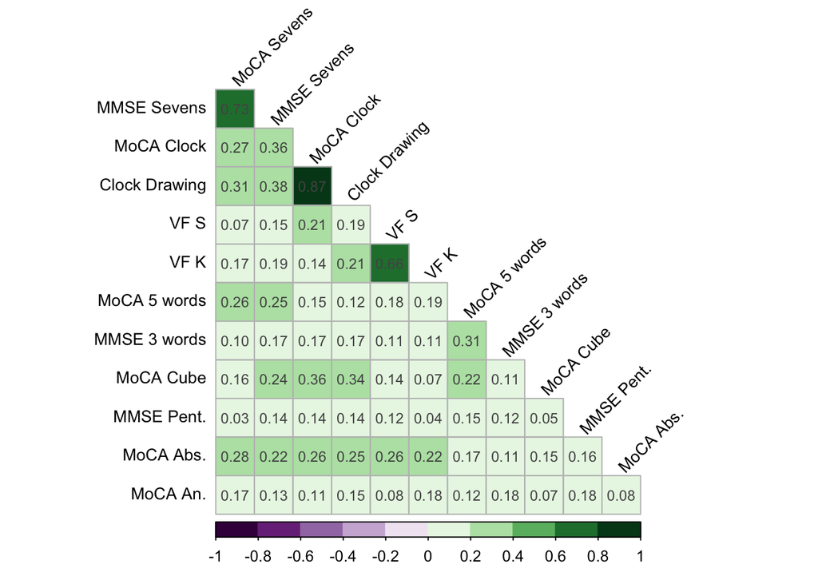

Correlation matrix of the candidate predictor pool.

```r
plot_correlation(tar_read(index_correlations, store = upstore)$R_observed)
```

### Prior Specification

**To mitigate risks associated with multicollinearity and overfitting, all regression coefficients barring the intercept were assigned regularized horseshoe priors (Piironen and Vehtari 2017a). Specifically,**

$$\beta_j \sim Horseshoe(\tau,
\lambda_j)$$

**where $\lambda_j$ represents item-specific local shrinkage parameter and $\tau$ represents the global shrinkage parameter controlling overall sparsity.**

**The prior was implemented using the `horseshoe()` function from the *brms* package (Bürkner 2017) with parameters $df = 3$ and $par\_ratio = r$, where $r$ reflect the ratio of expected non-zero parameters to the full predictor set. In the present analysis, $r$ was based on 4 or 5 expected non-zero parameters to reflect the expectation that only a minority of screening variables would meaningfully contribute to prediction. Specifically, Dubois et al. (2007) define 4 domains to define cognitive impairment on Level I, while Kulisevsky et al. (2024) suggest to add fifth, language domain.**

**The intercept parameter was assigned uniform prior as per *brms* defaults.**

**The reference model included four chains, each running for 1,000 warmup (later discarded) iterations, and 2,500 further iterations of a Hamiltonian Monte Carlo (HMC) algorithm, resulting in 10,000 samples from the posterior distribution. The model were fitted using the HMC sampler in Stan (version 2.32.2) (Carpenter et al. 2017)**

### Projection Predictive Variable Selection

**Following estimation of the reference model, projection predictive variable selection was conducted using the R package *projpred* (Piironen et al. 2025).**

**The procedure evaluates a sequence of reduced submodels containing progressively smaller subset of predictors. For each candidate submodel, the predictive distribution is obtained by projecting the reference model posterior onto the reduced model parameter space, ensuring that the reduced submodel approximates the prediction made by the reference model.**

**Predictive performance was evaluated using the expected log pointwise predictive density (ELPD) estimated via cross-validation unsing the `cv_varsel()` function with 20 clusters and 1,000 draws from the posterior.**

**Model size was determined using the following heuristic with combination of visual examination of ELPD difference plots: for selection, the smallest submodels were considered for which the upper bound of the 68.3% normal-approximation interval (+/- 1 SD) of the submodel exceeded the ELPD estimate of the reference model.**

**Results of ELPD comparisons are presented in (**fig-projpred?**). When FAQ item 9 score was used to define IADL impairment, none of the predictors was selected by the heuristic ((**fig-projpred?**) C). On the other hand, unde the FAQ total score definition of IADL impairment, either two or six predictors were selected by the heuristic ((**fig-projpred?**) A and B). The pattern of results was similar for $r = 4$ and $r = 5$ and the exact results differed between runs of the modelling pipeline due to randomness in the sampling process.**

**Given the overall pattern of ELPD differences (showing clear improvement when two predictors are selected with clear deterior of predictive performance when selecting three to five predictors), and greater parsimony of two compared to six predictors, the two-predictor classification model was selected for further analysis. (**fig-projpred-rk?**) shows cummulative ranking of the predictors based on the number of cross-validation folds in which each predictor was included to progressively smaller submodels.**

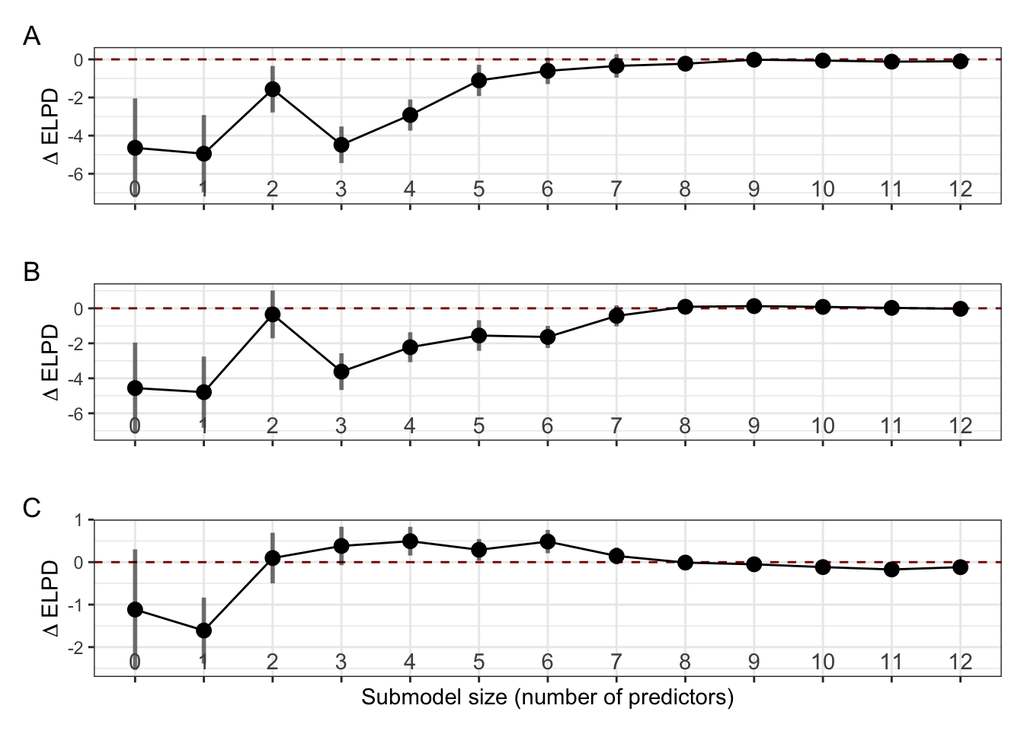

Expected log pointwise predictive density (ELPD) comparison.

```r
format_it <- function(p) {
  p +
    theme_bw() +
    theme(
      axis.text.x.bottom = element_blank(),
      plot.title = element_blank(),
      plot.subtitle = element_blank(),
      strip.background = element_blank(),
      strip.text = element_blank()
    )
}

p1 <- format_it(pred_mods$vs_plots[[1]]$plot_pp) + labs(x = "", y = expression(Delta~ELPD))
p2 <- format_it(pred_mods$vs_plots[[2]]$plot_pp) + labs(x = "", y = expression(Delta~ELPD))
p3 <- format_it(pred_mods$vs_plots[[3]]$plot_pp) + labs(x = "Submodel size (number of predictors)", y = expression(Delta~ELPD))

p1 / p2 / p3 + plot_annotation(tag_levels = "A")
```

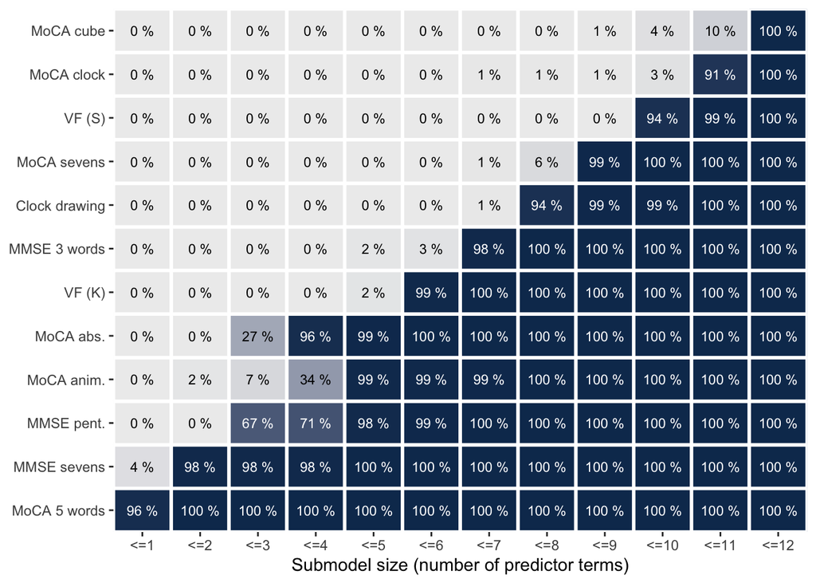

Cummulative ranking of predictors from the process of selection of the final screening models.

```r
x <- c(
  "MoCA 5 words",
  "MMSE sevens",
  "MMSE pent.",
  "MoCA anim.",
  "MoCA abs.",
  "VF (K)",
  "MMSE 3 words",
  "Clock drawing",
  "MoCA sevens",
  "VF (S)",
  "MoCA clock",
  "MoCA cube"
)

pred_mods$vs_plots[[1]]$plot_rk_cum +
  scale_y_discrete(labels = x) +
  labs(y = NULL) +
  theme(legend.position = "none")
```

### Decision Threshold Estimation

**To derive a practical screening rule, the optimal probability threshold for predicting Level II PDD classification was determined using the modified Youden index proposed by Perkins and Schisterman (2006). The modification parameter $r_p$ was varied between:**

$r_p \in \{0.1, 0.2, 0.3, 0.4, 0.5\}$

**to reflect plausible population prevalence values for PDD.**

**Finally, a screening decision equations for each unique optimal threshold were derived by re-weigthing the following inequality:**

$$\sum_{j=1}^{M} \beta_j x_{ij} \leq
(threshold - \beta_0)$$

**where $M$ is the number of selected predictors by the smallest $\beta_j$, i.e., $min(\beta)$, resulting into a clinical screening rule equation[^3]:**

$$\sum_{j=1}^{M}
\frac{\beta_j}{min(\beta)} x_{ij} \leq \frac{(threshold -
\beta_0)}{min(\beta)}$$
.

{{< pagebreak >}}

## Supplementary Presentation of Results

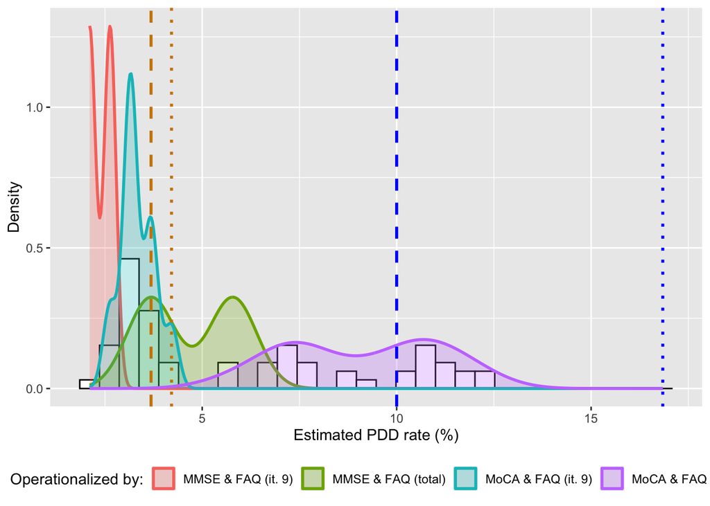

Summary of the estimates of probable PDD rate.

```r
rates$plot
```

```r
rates$gtables$rates
```

| Algorithm | N | Rate |
| --- | --- | --- |
| sMoCA (1) | 190 | 32 (16.84%) |
| MoCA (53) | 190 | 23 (12.11%) |
| MoCA (57) | 190 | 23 (12.11%) |
| MoCA (45) | 190 | 22 (11.58%) |
| MoCA (49) | 190 | 22 (11.58%) |
| MoCA (33) | 190 | 21 (11.05%) |
| MoCA (37) | 190 | 21 (11.05%) |
| MoCA (59) | 190 | 21 (11.05%) |
| MoCA (13) | 190 | 20 (10.53%) |
| MoCA (17) | 190 | 20 (10.53%) |
| MoCA (29) | 190 | 20 (10.53%) |
| MoCA (55) | 190 | 20 (10.53%) |
| MoCA (9) | 190 | 20 (10.53%) |
| Lvl.II (1) | 190 | 19 (10.00%) |
| MoCA (41) | 190 | 19 (10.00%) |
| MoCA (51) | 190 | 19 (10.00%) |
| MoCA (5) | 190 | 18 (9.47%) |
| MoCA (25) | 190 | 17 (8.95%) |
| MoCA (47) | 190 | 17 (8.95%) |
| MoCA (1) | 190 | 15 (7.89%) |
| MoCA (19) | 190 | 15 (7.89%) |
| MoCA (39) | 190 | 15 (7.89%) |
| MoCA (11) | 190 | 14 (7.37%) |
| MoCA (15) | 190 | 14 (7.37%) |
| MoCA (21) | 190 | 14 (7.37%) |
| MoCA (35) | 190 | 14 (7.37%) |
| MoCA (43) | 190 | 14 (7.37%) |
| MoCA (27) | 190 | 13 (6.84%) |
| MoCA (31) | 190 | 13 (6.84%) |
| MoCA (7) | 190 | 13 (6.84%) |
| MMSE (1) | 190 | 11 (5.79%) |
| MoCA (23) | 190 | 11 (5.79%) |
| MoCA (3) | 190 | 11 (5.79%) |
| MoCA (52) | 190 | 8 (4.21%) |
| MoCA (56) | 190 | 8 (4.21%) |
| MoCA (60) | 190 | 8 (4.21%) |
| sMoCA (2) | 190 | 8 (4.21%) |
| Lvl.II (2) | 190 | 7 (3.68%) |
| MMSE (3) | 190 | 7 (3.68%) |
| MoCA (12) | 190 | 7 (3.68%) |
| MoCA (16) | 190 | 7 (3.68%) |
| MoCA (20) | 190 | 7 (3.68%) |
| MoCA (46) | 190 | 7 (3.68%) |
| MoCA (48) | 190 | 7 (3.68%) |
| MoCA (50) | 190 | 7 (3.68%) |
| MoCA (54) | 190 | 7 (3.68%) |
| MoCA (58) | 190 | 7 (3.68%) |
| MoCA (10) | 190 | 6 (3.16%) |
| MoCA (14) | 190 | 6 (3.16%) |
| MoCA (18) | 190 | 6 (3.16%) |
| MoCA (24) | 190 | 6 (3.16%) |
| MoCA (28) | 190 | 6 (3.16%) |
| MoCA (30) | 190 | 6 (3.16%) |
| MoCA (32) | 190 | 6 (3.16%) |
| MoCA (34) | 190 | 6 (3.16%) |
| MoCA (36) | 190 | 6 (3.16%) |
| MoCA (38) | 190 | 6 (3.16%) |
| MoCA (40) | 190 | 6 (3.16%) |
| MoCA (42) | 190 | 6 (3.16%) |
| MoCA (44) | 190 | 6 (3.16%) |
| MoCA (6) | 190 | 6 (3.16%) |
| MoCA (8) | 190 | 6 (3.16%) |
| MMSE (2) | 190 | 5 (2.63%) |
| MoCA (2) | 190 | 5 (2.63%) |
| MoCA (22) | 190 | 5 (2.63%) |
| MoCA (26) | 190 | 5 (2.63%) |
| MoCA (4) | 190 | 5 (2.63%) |
| MMSE (4) | 190 | 4 (2.11%) |

*Note.* Percentages were calculated from all available cases, the items comprising each listed algorithm can be found in Table A1.

```r
approx_bal$gtable
```

| Level II (1)<sup>a</sup> Predictor | Level II (1)<sup>a</sup> κ | Level II (1)<sup>a</sup> Accuracy | Level II (1)<sup>a</sup> p | Level II (1)<sup>a</sup> Sensitivity | Level II (1)<sup>a</sup> Specificity | Level II (2)<sup>b</sup> Predictor | Level II (2)<sup>b</sup> κ | Level II (2)<sup>b</sup> Accuracy | Level II (2)<sup>b</sup> p | Level II (2)<sup>b</sup> Sensitivity | Level II (2)<sup>b</sup> Specificity |
| --- | --- | --- | --- | --- | --- | --- | --- | --- | --- | --- | --- |
| Top five |  |  |  |  |  |  |  |  |  |  |  |
| sMoCA (1) | 0.69 | 0.93 | .093 | 0.95 | 0.92 | MoCA (12) | 0.85 | 0.99 | .028 | 0.86 | 0.99 |
| MoCA (45) | 0.68 | 0.94 | .032 | 0.75 | 0.96 | MoCA (16) | 0.85 | 0.99 | .028 | 0.86 | 0.99 |
| MoCA (49) | 0.68 | 0.94 | .032 | 0.75 | 0.96 | MoCA (20) | 0.85 | 0.99 | .028 | 0.86 | 0.99 |
| MoCA (53) | 0.66 | 0.93 | .056 | 0.75 | 0.95 | MoCA (52) | 0.79 | 0.98 | .078 | 0.86 | 0.99 |
| MoCA (57) | 0.66 | 0.93 | .056 | 0.75 | 0.95 | MoCA (56) | 0.79 | 0.98 | .078 | 0.86 | 0.99 |
| Bottom five |  |  |  |  |  |  |  |  |  |  |  |
| MoCA (21) | 0.55 | 0.93 | .093 | 0.50 | 0.98 | MoCA (58) | 0.70 | 0.98 | .168 | 0.71 | 0.99 |
| MoCA (35) | 0.55 | 0.93 | .093 | 0.50 | 0.98 | MoCA (22) | 0.66 | 0.98 | .168 | 0.57 | 0.99 |
| MoCA (39) | 0.53 | 0.92 | .143 | 0.50 | 0.97 | MoCA (26) | 0.66 | 0.98 | .168 | 0.57 | 0.99 |
| MMSE (1) | 0.55 | 0.93 | .056 | 0.45 | 0.99 | MMSE (2) | 0.66 | 0.98 | .168 | 0.57 | 0.99 |
| MMSE (3) | 0.43 | 0.93 | .136 | 0.32 | 0.99 | MMSE (4) | 0.53 | 0.97 | .296 | 0.43 | 0.99 |

<sup>a</sup> IADL deficit was defined as FAQ (total score) > 7  
<sup>b</sup> IADL deficit was defined as FAQ (item 9) > 1  
κ: Cohen's κ; p: p-value associated with a one-sided Exact Binomial Test comparing the Accuracy to the No Information Rate; The table shows five most accurate (Top five) and five least accurate (Bottom five) Level I algorithms for Parkinson's Disease Dementia (PDD) in predicting Level II classificiation of PDD. The algorithms were grouped by their definition of the deficit in Instrumental Activities of Daily Living (IADLs). The items comprising each listed algorithm can be found in Table A1.

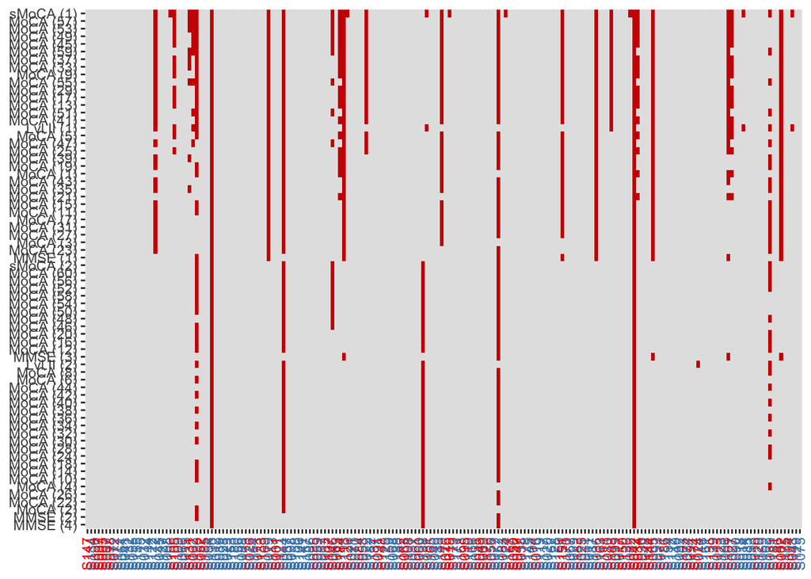

Representation of study data.

```r
pred$plots$data
```

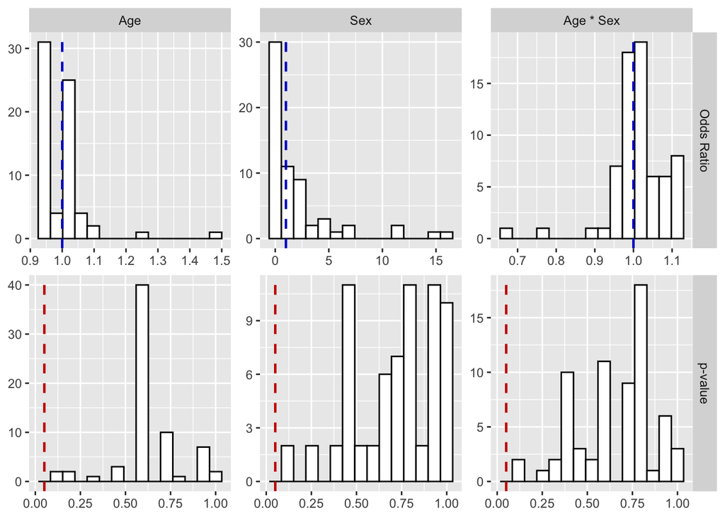

Summary of logistic regressions parameters prediction probable PDD by age and sex.

```r
pred$plots$parameters
```

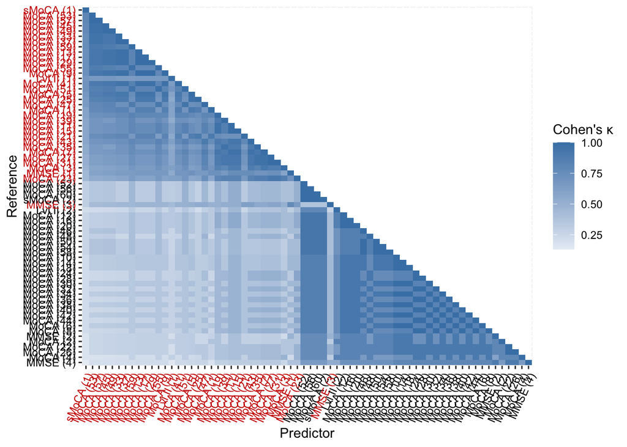

Cohen’s κ matrix.

```r
conc$plots$Kappa
```

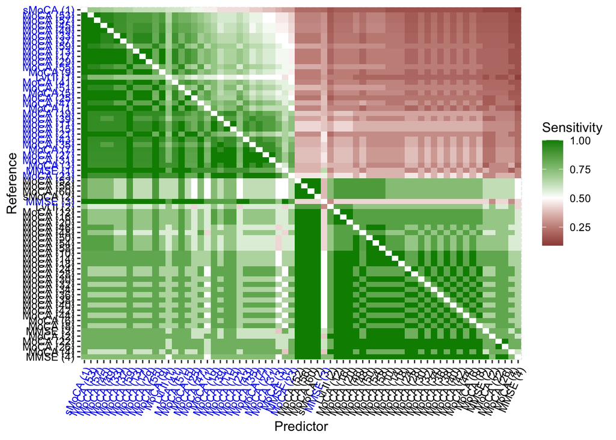

Sensitivity matrix.

```r
conc$plots$Sensitivity
```

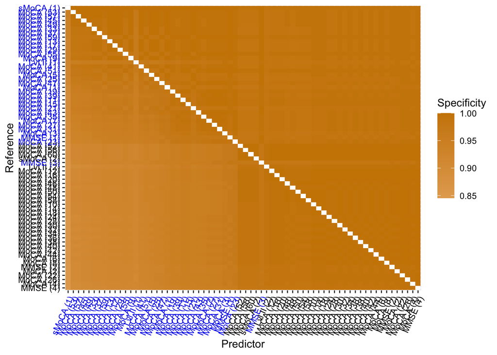

Specificity matrix.

```r
conc$plots$Specificity
```

Aarsland, Dag, Julia Zaccai, and Carol Brayne. 2005. “A Systematic Review of Prevalence Studies of Dementia in Parkinson’s Disease.” *Movement Disorders: Official Journal of the Movement Disorder Society* 20 (10): 1255–63. https://doi.org/10.1016/j.parkreldis.2011.05.017.

Beck, Aaron T., R. A. Steer, and G. Brown. 1996. “Beck Depression InventoryII.” American Psychological Association (APA). https://doi.org/10.1037/t00742-000.

Benedict, Ralph H. B. 1997. *Brief Visuospatial Memory Test Revised: Professional Manual*. Odessa, FL: Psychological Assessment Resources.

Benton, A. L., N. R. Varney, and K. Hamsher. 1983. “Visuospatial Judgment: A Clinical Test.” *Archives of Neurology* 40 (3): 429–32. https://doi.org/10.1001/archneur.1978.00500300038006.

Bezdicek, O., J. Lukavský, and M. Preiss. 2011. “Functional Activities Questionnaire, Czech Version – a Validation Study.” *Česká a Slovenská Neurologie a Neurochirurgie* 74 (107): 36–42. https://www.csnn.eu/casopisy/ceska-slovenska-neurologie/2011-1/validizacni-studie-ceske-verze-dotazniku-faq-34140.

Bezdicek, O., L. Motak, B. N. Axelrod, M. Preiss, T. Nikolai, M. Vyhnalek, A. Poreh, and E. Ruzicka. 2012. “Czech Version of the Trail Making Test: Normative Data and Clinical Utility.” *Archives of Clinical Neuropsychology* 27 (8): 906–14. https://doi.org/10.1093/arclin/acs084.

Bezdicek, Ondrej, M. Červenková, T. M. Moore, H. S. Georgi, Z. Sulc, D. A. Wolk, D. A. Weintraub, et al. 2020. “Determining a Short Form Montreal Cognitive Assessment (s-MoCA) Czech Version: Validity in Mild Cognitive Impairment Parkinson’s Disease and Cross-Cultural Comparison.” *Assessment* 27 (8): 1960–70. https://doi.org/10.1177/1073191118778896.

Bezdicek, Ondřej, Hana Georgi, Tomáš Nikolai, and Miloslav Kopeček. 2021. *Pražská Verze Stroopova Testu*. Praha: Karolinum. https://karolinum.cz/en/books/bezdicek-prazska-verze-stroopova-testu-25158.

Bezdicek, Ondrej, Josef Mana, Melisa Schneiderová, Zuzana Kasáková, Miloslav Kopecek, and Miloslav Georgi. 2024. “An Interplay Between Cross-Cultural and Psychometric Factors in the Montreal Cognitive Assessment: Experience from the Language of a Small Nation.” *Applied Neuropsychology: Adult* 0 (0): 1–8. https://doi.org/10.1080/23279095.2024.2397041.

Bezdicek, Ondrej, Tomas Nikolai, Jiri Michalec, Filip Růžička, Petra Havránková, Jan Roth, Robert Jech, and Evžen Růžička. 2016. “The Diagnostic Accuracy of Parkinson’s Disease Mild Cognitive Impairment Battery Using the Movement Disorder Society Task Force Criteria.” *Movement Disorders Clinical Practice* 4 (2): 237–44. https://doi.org/10.1002/mdc3.12391.

Bezdicek, Ondrej, Hana Stepankova, Lenka Martinec Novakova, and Miloslav Kopecek. 2016. “Toward the Processing Speed Theory of Activities of Daily Living in Healthy Aging: Normative Data of the Functional Activities Questionnaire.” *Aging Clinical and Experimental Research* 28: 239–47.

Bezdicek, Ondrej, Hana Stepankova, Ladislav Moták, Bradley N. Axelrod, John L. Woodard, Marek Preiss, Tomáš Nikolai, Evžen Růžička, and Amir Poreh. 2013. “Czech Version of Rey Auditory Verbal Learning Test: Normative Data.” *Aging, Neuropsychology, and Cognition* 21 (6): 693–721. https://doi.org/10.1080/13825585.2013.865699.

Bezdicek, Ondrej, Zdenek Sulc, Tomas Nikolai, Hana Stepankova, Miloslav Kopecek, Robert Jech, and Evžen Růžička. 2017. “A Parsimonious Scoring and Normative Calculator for the Parkinson’s Disease Mild Cognitive Impairment Battery.” *The Clinical Neuropsychologist* 31 (6-7): 1231–47. https://doi.org/10.1080/13854046.2017.1293161.

Bove, Francesco, Valerie Fraix, Francesco Cavallieri, Emmanuelle Schmitt, Eugénie Lhommée, Amélie Bichon, Sara Meoni, et al. 2020. “Dementia and Subthalamic Deep Brain Stimulation in Parkinson Disease.” *Neurology* 95 (4): e384–92. https://doi.org/10.1212/WNL.0000000000009822.

Brennan, Laura, Andrew Siderowf, Jonathan D. Rubright, Jacqueline Rick, Nabila Dahodwala, John E. Duda, Howard Hurtig, et al. 2016. “The Penn Parkinson’s Daily Activities Questionnaire-15: Psychometric Properties of a Brief Assessment of Cognitive Instrumental Activities of Daily Living in Parkinson’s Disease.” *Parkinsonism & Related Disorders* 25 (April): 21–26. https://doi.org/10.1016/j.parkreldis.2016.02.020.

Bronstein, Jeff M., Michele Tagliati, Ron L. Alterman, Andres M. Lozano, Jens Volkmann, Alessandro Stefani, Fay B. Horak, et al. 2011. “Deep Brain Stimulation for Parkinson Disease.” *Archives of Neurology* 68 (2). https://doi.org/10.1001/archneurol.2010.260.

Bürkner, Paul-Christian. 2017. “brms: An R Package for Bayesian Multilevel Models Using Stan.” *Journal of Statistical Software* 80 (1): 1–28. https://doi.org/10.18637/jss.v080.i01.

Carpenter, Bob, Andrew Gelman, Matthew D. Hoffman, Daniel Lee, Ben Goodrich, Michael Betancourt, Marcus Brubaker, Jiqiang Guo, Peter Li, and Allen Riddell. 2017. “*Stan*: A Probabilistic Programming Language.” *Journal of Statistical Software* 76 (1). https://doi.org/10.18637/jss.v076.i01.

Cereda, Emanuele, Roberto Cilia, Catherine Klersy, Chiara Siri, Beatrice Pozzi, Elisa Reali, Aurora Colombo, et al. 2016. “Dementia in Parkinson’s Disease: Is Male Gender a Risk Factor?” *Parkinsonism & Related Disorders* 26: 67–72. https://doi.org/10.1016/j.parkreldis.2016.02.024.

Ciharova, Marketa, Hynek Cígler, Veronika Dostálová, Gabriela Šivicová, and Ondrej Bezdicek. 2020. “Beck Depression Inventory, Second Edition, Czech Version: Demographic Correlates, Factor Structure and Comparison with Foreign Data.” *International Journal of Psychiatry in Clinical Practice* 24 (4): 371–79. https://doi.org/10.1080/13651501.2020.1775854.

Dubois, Bruno, David Burn, Christopher Goetz, Dag Aarsland, Richard G. Brown, Gerald A. Broe, Dennis Dickson, et al. 2007. “Diagnostic Procedures for Parkinson’s Disease Dementia: Recommendations from the Movement Disorder Society Task Force.” *Movement Disorders* 22 (16): 2314–24. https://doi.org/10.1002/mds.21844.

Emre, Murat, Dag Aarsland, Richard Brown, David J. Burn, Charles Duyckaerts, Yoshikino Mizuno, Gerald Anthony Broe, et al. 2007. “Clinical Diagnostic Criteria for Dementia Associated with Parkinson’s Disease.” *Movement Disorders* 22 (12): 1689–1707. https://doi.org/10.1002/mds.21507.

Folstein, Marshal F., Susan E. Folstein, and Paul R. McHugh. 1975. ““Mini-Mental State”.” *Journal of Psychiatric Research* 12 (3): 189–98. https://doi.org/10.1016/0022-3956(75)90026-6.

Frydrychová, Zuzana, Miloslav Kopeček, Ondřej Bezdicek, and Jana Štěpánková. 2018. “České Normy Pro Revidovaný Reyův Auditorně-Verbální Test Učení (RAVLT) Pro Populaci Starších Osob.” *Československá Psychologie* 62 (4): 330–49. https://cejsh.icm.edu.pl/cejsh/element/bwmeta1.element.02da6923-6394-4d8d-b018-dd6e3b2503be.

Havlı́k, Filip, Josef Mana, Petr Dušek, Robert Jech, Evžen Ržička, Miloslav Kopeček, Hana Georgi, and Ondrej Bezdicek. 2020. “Brief Visuospatial Memory Test-Revised: Normative Data and Clinical Utility of Learning Indices in Parkinson’s Disease.” *Journal of Clinical and Experimental Neuropsychology* 42 (10): 1099–1110.

Iannone, Richard, Joe Cheng, Barret Schloerke, Ellis Hughes, Alexandra Lauer, JooYoung Seo, Ken Brevoort, and Olivier Roy. 2024. *Gt: Easily Create Presentation-Ready Display Tables*. https://CRAN.R-project.org/package=gt.

Kaplan, Edith, Harold Goodglass, and Sandra Weintraub. 1983. *Boston Naming Test*. Philadelphia, PA: Lea & Febiger.

Kehagia, Angie A, Roger A Barker, and Trevor W Robbins. 2012. “Cognitive Impairment in Parkinson’s Disease: The Dual Syndrome Hypothesis.” *Neurodegenerative Diseases* 11 (2): 79–92. https://doi.org/10.1159/000341998.

Kopecek, Miloslav, Hana Stepankova, Jiri Lukavsky, Daniela Ripova, Tomas Nikolai, and Ondrej Bezdicek. 2016. “Montreal Cognitive Assessment (MoCA): Normative Data for Old and Very Old Czech Adults.” *Applied Neuropsychology: Adult* 24 (1): 23–29. https://doi.org/10.1080/23279095.2015.1065261.

Kuhn, Max. 2008. “Building Predictive Models in r Using the Caret Package.” *Journal of Statistical Software* 28 (5): 1–26. https://doi.org/10.18637/jss.v028.i05.

Kulisevsky, Jaime, Irene Litvan, Daniel Weintraub, Jennifer G Goldman, Alexander I Tröster, Simon JG Lewis, International Parkinson, Movement Disorder Society PD-MCI Study Group, et al. 2024. “A Call for Change: Updating the Operational Definition for Dementia in Parkinson’s Disease.” *Movement Disorders Clinical Practice* 12 (3): 296–301. https://doi.org/10.1002/mdc3.14305.

Litvan, Irene, Jennifer G. Goldman, Alexander I. Tröster, Ben A. Schmand, Daniel Weintraub, Ronald C. Petersen, Brit Mollenhauer, et al. 2012. “Diagnostic Criteria for Mild Cognitive Impairment in Parkinson’s Disease: *Movement* Disorder Society Task Force Guidelines.” *Movement Disorders* 27 (3): 349–56. https://doi.org/10.1002/mds.24893.

Lundberg, Ian, Rebecca Johnson, and Brandon M. Stewart. 2021. “What Is Your Estimand? Defining the Target Quantity Connects Statistical Evidence to Theory.” *American Sociological Review* 86 (3): 532–65. https://doi.org/10.1177/00031224211004187.

Mana, Josef, Ondrej Bezdicek, Filip Růžička, Andrej Lasica, Anna Šmídová, Olga Klempířová, Tomáš Nikolai, et al. 2024. “Preoperative Cognitive Profile Predictive of Cognitive Decline After Subthalamic Deep Brain Stimulation in Parkinson’s Disease.” *European Journal of Neuroscience* 60 (7): 5764–84. https://doi.org/https://doi.org/10.1111/ejn.16521.

McHugh, Marry L. 2012. “Interrater Reliability: The Kappa Statistic.” *Biochemia Medica*, 276–82. https://doi.org/10.11613/bm.2012.031.

Meireles, Joana, and João Massano. 2012. “Cognitive Impairment and Dementia in Parkinsons Disease: Clinical Features, Diagnosis, and Management.” *Frontiers in Neurology* 3. https://doi.org/10.3389/fneur.2012.00088.

Moheb, Negar, Mario F. Mendez, Sarah A. Kremen, and Edmond Teng. 2017. “Executive Dysfunction and Behavioral Symptoms Are Associated with Deficits in Instrumental Activities of Daily Living in Frontotemporal Dementia.” *Dementia and Geriatric Cognitive Disorders* 43 (1-2): 89–99. https://doi.org/10.1159/000455119.

Mullner, J., I. Ruisl, and G. Farkas. 1980. *Dotaznik Na Meranie Uzkosti a Uzkostlivosti - STAI*. Bratislava: Psychodiagnostické a didaktické testy.

Nasreddine, Ziad S., Natalie A. Phillips, Valérie Bédirian, Simon Charbonneau, Victor Whitehead, Isabelle Collin, Jeffrey L. Cummings, and Howard Chertkow. 2005. “The Montreal Cognitive Assessment, MoCA: A Brief Screening Tool For Mild Cognitive Impairment.” *Journal of the American Geriatrics Society* 53 (4): 695–99. https://doi.org/10.1111/j.1532-5415.2005.53221.x.

Nikolai, Tomaš, Hana Štěpánková, Jiří Michalec, Ondřej Bezdíček, Karolína Horáková, Hana Marková, Evžen Růžička, and Miloslav Kopeček. 2015. “Tests of Verbal Fluency, Czech Normative Study in Older Patients.” *Česká a Slovenská Neurologie a Neurochirurgie* 78/111 (3): 292–99. https://doi.org/10.14735/amcsnn2015292.

O’Donald, Freddie, and Clara Calia. 2025. “The Process of Translation and Cross-Cultural Adaptation of Functional Assessment Tools for Dementia: A Systematized Review.” *Health Science Reports* 8 (1). https://doi.org/10.1002/hsr2.70289.

Oh, Yoon-Sang, Joong-Seok Kim, In-Seok Park, Yong-Soo Shim, In-Uk Song, Jeong-Wook Park, Phil-Hyu Lee, et al. 2016. “Prevalence and Treatment Pattern of Parkinson’s Disease Dementia in Korea.” *Geriatrics & Gerontology International* 16 (2): 230–36.

Perkins, Neil J., and Enrique F. Schisterman. 2006. “The Inconsistency of ‘Optimal’ Cutpoints Obtained Using Two Criteria Based on the Receiver Operating Characteristic Curve.” *American Journal of Epidemiology* 163 (7): 670–75. https://doi.org/10.1093/aje/kwj063.

Pfeffer, R. I., T. T. Kurosaki, C. H. Harrah, J. M. Chance, and S. Filos. 1982. “Measurement of Functional Activities in Older Adults in the Community.” *Journal of Gerontology* 37 (3): 323–29. https://doi.org/10.1093/geronj/37.3.323.

Piironen, Juho, Markus Paasiniemi, Alejandro Catalina, Frank Weber, Osvaldo Martin, and Aki Vehtari. 2025. “projpred: Projection Predictive Feature Selection.” https://mc-stan.org/projpred/.

Piironen, Juho, Markus Paasiniemi, and Aki Vehtari. 2020. “Projective Inference in High-Dimensional Problems: Prediction and Feature Selection.” *Electronic Journal of Statistics* 14 (1): 2155–97. https://doi.org/10.1214/20-EJS1711.

Piironen, Juho, and Aki Vehtari. 2017a. “Comparison of Bayesian Predictive Methods for Model Selection.” *Statistics and Computing* 27 (3): 711–35. https://doi.org/10.1007/s11222-016-9649-y.

———. 2017b. “On the Hyperprior Choice for the Global Shrinkage Parameter in the Horseshoe Prior.” In *Proceedings of the 20th International Conference on Artificial Intelligence and Statistics*, edited by Aarti Singh and Jerry Zhu, 54:905–13. Proceedings of Machine Learning Research. PMLR. https://proceedings.mlr.press/v54/piironen17a.html.

Postema, Merel C., Mark A. Dubbelman, Jürgen Claesen, Craig Ritchie, Merike Verrijp, Leonie Visser, Pieter-Jelle Visser, Marissa D. Zwan, Wiesje M. van der Flier, and Sietske A. M. Sikkes. 2024. “Facilitating Clinical Use of the Amsterdam Instrumental Activities of Daily Living Questionnaire: Normative Data and a Diagnostic Cutoff Value.” *Journal of the International Neuropsychological Society* 30 (6): 615–20. https://doi.org/10.1017/s1355617724000031.

Postuma, Ronald B., Daniela Berg, Matthew Stern, Werner Poewe, C. Warren Olanow, Wolfgang Oertel, José Obeso, et al. 2015. “MDS Clinical Diagnostic Criteria for Parkinson’s Disease.” *Movement Disorders* 30 (12): 1591–601. https://doi.org/10.1002/mds.26424.

R Core Team. 2024. *R: A Language and Environment for Statistical Computing*. Vienna, Austria: R Foundation for Statistical Computing. https://www.R-project.org/.

Rana, Abdul Qayyum, Muhammad Saad Yousuf, Sughra Naz, and Nour Qa’aty. 2011. “Prevalence and Relation of Dementia to Various Factors in Parkinson’s Disease.” *Psychiatry and Clinical Neurosciences* 65 (4): 317–21. https://doi.org/10.1111/j.1440-1819.2011.02291.x.

Reitan, R. 2004. “The Trail Making Test as an Initial Screening Procedure for Neuropsychological Impairment in Older Children.” *Archives of Clinical Neuropsychology* 19 (2): 281–88. https://doi.org/10.1016/s0887-6177(03)00042-8.

Reppermund, Simone, Perminder S. Sachdev, John Crawford, Nicole A. Kochan, Melissa J. Slavin, Kristan Kang, Julian N. Trollor, Brian Draper, and Henry Brodaty. 2011. “The Relationship of Neuropsychological Function to Instrumental Activities of Daily Living in Mild Cognitive Impairment.” *International Journal of Geriatric Psychiatry* 26 (8): 843–52. https://doi.org/https://doi.org/10.1002/gps.2612.

Rey, André. 1964. *L’examen Clinique En Psychologie (the Clinical Psychological Examination)*. Paris: Presses Universitaires de France.

Roalf, David R., Tyler M. Moore, Dawn Mechanic-Hamilton, David A. Wolk, Steven E. Arnold, Daniel A. Weintraub, and Paul J. Moberg. 2017. “Bridging Cognitive Screening Tests in Neurologic Disorders: A Crosswalk Between the Short Montreal Cognitive Assessment and Mini-Mental State Examination.” *Alzheimer’s & Dementia* 13 (8): 947–52. https://doi.org/10.1016/j.jalz.2017.01.015.

Robin, Xavier, Natacha Turck, Alexandre Hainard, Natalia Tiberti, Frédérique Lisacek, Jean-Charles Sanchez, and Markus Müller. 2011. “pROC: An Open-Source Package for r and s+ to Analyze and Compare ROC Curves.” *BMC Bioinformatics* 12: 77.

Royall, D. R, J. A Cordes, and M. Polk. 1998. “CLOX: An Executive Clock Drawing Task.” *Journal of Neurology, Neurosurgery & Psychiatry* 64 (5): 588–94. https://doi.org/10.1136/jnnp.64.5.588.

Schmitter-Edgecombe, Maureen, Reanne Cunningham, Courtney McAlister, Kayela Arrotta, and Alyssa Weakley. 2020. “The Night Out Task and Scoring Application: An Ill-Structured, Open-Ended Clinic-Based Test Representing Cognitive Capacities Used in Everyday Situations.” *Archives of Clinical Neuropsychology* 36 (4): 537–53. https://doi.org/10.1093/arclin/acaa080.

Sousa, Catarina Severiano e, Joana Alarcão, Isabel Pavão Martins, and Joaquim J Ferreira. 2022. “Frequency of Dementia in Parkinson’s Disease: A Systematic Review and Meta-Analysis.” *Journal of the Neurological Sciences* 432: 120077. https://doi.org/10.1016/j.jns.2021.120077.

Spielberger, C. D., R. L. Gorsuch, R. Lushene, P. R. Vagg, and G. A. & Jacobs. 1983. *Manual for the State-Trait Anxiety Inventory*. Palo Alto, CA: Consulting Psychologists Press.

Stepankova, Hana, Tomas Nikolai, Jiri Lukavsky, Ondrej Bezdicek, M Vrajova, and Miloslav Kopecek. 2015. “Mini‑Mental State Examination – česká normativní studie.” *Ceska a slovenska neurologie a neurochirurgie* 78 (111): 57–63.

Summers, Dale, Kristie Spencer, Connie Okasaki, and Jessica E. Huber. 2024. “An Examination of Cognitive Heterogeneity in Parkinson Disease: The Dual-Syndrome Hypothesis.” *Journal of Speech, Language, and Hearing Research* 67 (4): 1127–35. https://doi.org/10.1044/2024\_JSLHR-23-00621.

Wechsler, David. 1997. *Wechsler Adult Intelligence Scale—Third Edition (WAIS-III)*. San Antonio, TX: Psychological Corporation. https://books.google.cz/books/about/Wais_III_Wechsler_Adult_Intelligence_Sca.html?id=qTCuGQAACAAJ.

Wickham, Hadley, Mara Averick, Jennifer Bryan, Winston Chang, Lucy D’Agostino McGowan, Romain François, Garrett Grolemund, et al. 2019. “Welcome to the tidyverse.” *Journal of Open Source Software* 4 (43): 1686. https://doi.org/10.21105/joss.01686.

William Revelle. 2024. *Psych: Procedures for Psychological, Psychometric, and Personality Research*. Evanston, Illinois: Northwestern University. https://CRAN.R-project.org/package=psych.

Williams-Gray, Caroline H, Jonathan R. Evans, An Goris, Thomas Foltynie, Maria Ban, Trevor W. Robbins, Carol Brayne, et al. 2009. “The distinct cognitive syndromes of Parkinson’s disease: 5 year follow-up of the CamPaIGN cohort.” *Brain* 132 (11): 2958–69. https://doi.org/10.1093/brain/awp245.

Zemanová, N, O Bezdı́ček, J Michalec, T Nikolai, J Roth, R Jech, and E Ržička. 2016. “Validačnı́ Studie české Verze Bostonského Testu Pojmenovánı́.” *Česká a Slovenská Neurologie a Neurochirurgie* 79 (112): 3. https://doi.org/10.14735/amcsnn2016307.

[^1]: The candidate predictors thus included MMSE Sevens, MMSE Pentagons, MMSE Three words, Verbal Fluency S, Clock Drawing (as scored by Dubois et al. (2007)), MoCA Sevens, MoCA Cube, MoCA Five words, Verbal Fluency K, MoCA Clock drawing, MoCA Animal naming and MoCA Abstraction.
[^2]: Due to the large number of entries (4624 rows x 21 columns representing pairwise comparisons and metrics of interest respectively), the table with numerical results is not presented here or in the Appendix. Instead, we share the table share as data in the accompanying R package available at https://github.com/josefmana/demcrit.git. To obtain the table in format not dependent on R, follow the tutorial at https://josefmana.github.io/demcrit/articles/concordance.html
[^3]: Because the predictor variables were scaled before model computations, implementation of this equation included further step of back-transforming parameters to their respective response scales. This step was omitted from the description for conceptual clarity, but it can be checked on the study’s repository https:://github.com/josefmana/demcrit.git